# Statystyka i Analiza Danych 2023

## Mikołaj Wegner, 151177, lab: L6

# Pobranie i przygotowanie datasetu

Importowanie wszystkich potrzebnych bibliotek

```python
import pandas as pd
import matplotlib.pyplot as plt
import numpy as np
import seaborn as sns
from tabulate import tabulate
import warnings
warnings.filterwarnings('ignore')
```

Wybrałem partner_id 9FF550C0B17A3C493378CB6E2DEEE6E4, ponieważ po przejrzeniu danych uznałem, że jest całkiem dobra proporcja między sprzedażami a brakiem sprzedaży produktu

```python
file = r'C:\Users\miko2\PycharmProjects\SiAD\Resources\partner_id_9FF550C0B17A3C493378CB6E2DEEE6E4.csv'
```

Nazwy kolumn datasetu

```python
colnames = ['Sale', 'SalesAmountInEuro', 'time_delay_for_conversion',
            'click_timestamp', 'nb_clicks_1week', 'product_price',
            'product_age_group', 'device_type', 'audience_id',
            'product_gender', 'product_brand', 'product_category(1)',
            'product_category(2)', 'product_category(3)', 'product_category(4)',
            'product_category(5)', 'product_category(6)', 'product_category(7)',
            'product_country', 'product_id', 'product_title',
            'partner_id', 'user_id']
```

Import datasetu

```python
df = pd.read_csv(file, names=colnames, engine='python', header=None)
print("Imported the population")
```

```
Imported the population
```

Na początku sprawdzam jak wygląda dataset.

```python
df.head()
```

|  | Sale | SalesAmountInEuro | time_delay_for_conversion | click_timestamp | nb_clicks_1week | product_price | product_age_group | device_type | audience_id | product_gender | ... | product_category(3) | product_category(4) | product_category(5) | product_category(6) | product_category(7) | product_country | product_id | product_title | partner_id | user_id |
| --- | --- | --- | --- | --- | --- | --- | --- | --- | --- | --- | --- | --- | --- | --- | --- | --- | --- | --- | --- | --- | --- |
| 0 | 0 | -1.00000 | -1 | 1601437273 | 6 | 0.00 | 4C90FD52FC53D2C1C205844CB69575AB | D7D1FB49049702BF6338894757E0D959 | -1 | A5D15FC386510762EC0DDFF54ABE6F94 | ... | 8A30BF8BD2B3E9D44D2938D42C387D2E | -1 | -1 | -1 | -1 | 2AC62132FBCFA093B9426894A4BC6278 | 77AEF49D383E58FA384E99C177BF62D6 | F0F9816E146A3DF9B8A99B3B12A77362 922FACDC63DBA... | 9FF550C0B17A3C493378CB6E2DEEE6E4 | BB3F8CAD8C5AAF88CD7BE8C6FC356A2D |
| 1 | 0 | -1.00000 | -1 | 1601384595 | 14 | 0.00 | 4C90FD52FC53D2C1C205844CB69575AB | FF2C446555E3822B0E0FC3406116E86D | 13F966B23C28D8A8FECAFC2FC2CD7E00 | A5D15FC386510762EC0DDFF54ABE6F94 | ... | 2E4ED2B95CEF7FD11B282CDFDD56CEA0 | -1 | -1 | -1 | -1 | 2AC62132FBCFA093B9426894A4BC6278 | 3D55D8AEBBDAA58EB5FAA244601242D3 | 777BEECAD173AC93E5CE0CE1CC82DF15 65C0CABE6A2B2... | 9FF550C0B17A3C493378CB6E2DEEE6E4 | 8275B52D8FD8CBDA13BC2B36F110856C |
| 2 | 0 | -1.00000 | -1 | 1601369627 | 5 | 0.00 | 4C90FD52FC53D2C1C205844CB69575AB | FF2C446555E3822B0E0FC3406116E86D | -1 | A5D15FC386510762EC0DDFF54ABE6F94 | ... | 0279CBF3081FFB710CE52B9E0BA4AABF | 35A13FB2AB63E920B7D71C5957131606 | -1 | -1 | -1 | 2AC62132FBCFA093B9426894A4BC6278 | FADA68550BC65EF5F94718C02E437AA8 | C1B4729F10A2EA1402FBFB449E38825F 078EE401D7044... | 9FF550C0B17A3C493378CB6E2DEEE6E4 | 63D63E591416C1DD1EA80474EFD36E99 |
| 3 | 1 | 91.61788 | 619 | 1601422663 | 8 | 107.99 | 4C90FD52FC53D2C1C205844CB69575AB | D7D1FB49049702BF6338894757E0D959 | F432D202376506262B3F24AD1D565D4F | A5D15FC386510762EC0DDFF54ABE6F94 | ... | 0279CBF3081FFB710CE52B9E0BA4AABF | 35A13FB2AB63E920B7D71C5957131606 | -1 | -1 | -1 | 2AC62132FBCFA093B9426894A4BC6278 | 4EB3BA0A95DCD9C6B9906C160C7FE4BD | C1B4729F10A2EA1402FBFB449E38825F 078EE401D7044... | 9FF550C0B17A3C493378CB6E2DEEE6E4 | 1CFBA4098ABC71751ECEEDFE2D59BE4D |
| 4 | 1 | 23.79454 | 1855650 | 1601377189 | 23 | 13.99 | 4C90FD52FC53D2C1C205844CB69575AB | FF2C446555E3822B0E0FC3406116E86D | 32B8ABA7E55F4BB8356338F743EA37AF | A5D15FC386510762EC0DDFF54ABE6F94 | ... | C08050B58F54FA81F4580ECE15296698 | 067525A83E1875CB1828F4F9ADC752F6 | -1 | -1 | -1 | 2AC62132FBCFA093B9426894A4BC6278 | 5EAD3217B11B8F3DFF3403453E9A53AD | 4BCB07CC282329F41EF71E62693EBDAA 08DE6267A8660... | 9FF550C0B17A3C493378CB6E2DEEE6E4 | 692FB9599DAB1062AC09F218323CAB25 |

5 rows × 23 columns

Kształt datasetu (liczba wierszy x liczba kolumn)

```python
df.shape
```

```
(235228, 23)
```

Nazwy kolumn (pierwsze 3 - output) (reszta - cechy datasetu)

```python
df.columns
```

```
Index(['Sale', 'SalesAmountInEuro', 'time_delay_for_conversion',
       'click_timestamp', 'nb_clicks_1week', 'product_price',
       'product_age_group', 'device_type', 'audience_id', 'product_gender',
       'product_brand', 'product_category(1)', 'product_category(2)',
       'product_category(3)', 'product_category(4)', 'product_category(5)',
       'product_category(6)', 'product_category(7)', 'product_country',
       'product_id', 'product_title', 'partner_id', 'user_id'],
      dtype='object')
```

Opis zmiennych numerycznych datasetu.

```python
df.describe()
```

|  | Sale | SalesAmountInEuro | time_delay_for_conversion | click_timestamp | nb_clicks_1week | product_price | product_category(7) |
| --- | --- | --- | --- | --- | --- | --- | --- |
| count | 235228.000000 | 235228.000000 | 2.352280e+05 | 2.352280e+05 | 235228.000000 | 235228.000000 | 235228.0 |
| mean | 0.198556 | 31.641324 | 9.645719e+04 | 1.601096e+09 | 54.649506 | 14.135307 | -1.0 |
| std | 0.398914 | 140.393152 | 3.660513e+05 | 1.990324e+06 | 144.322775 | 51.832996 | 0.0 |
| min | 0.000000 | -1.000000 | -1.000000e+00 | 1.596440e+09 | -1.000000 | 0.000000 | -1.0 |
| 25% | 0.000000 | -1.000000 | -1.000000e+00 | 1.599576e+09 | 2.000000 | 0.000000 | -1.0 |
| 50% | 0.000000 | -1.000000 | -1.000000e+00 | 1.601104e+09 | 10.000000 | 0.000000 | -1.0 |
| 75% | 0.000000 | -1.000000 | -1.000000e+00 | 1.602795e+09 | 41.000000 | 0.000000 | -1.0 |
| max | 1.000000 | 15296.655370 | 2.586751e+06 | 1.604302e+09 | 1724.000000 | 12300.000000 | -1.0 |

# Eksploracyjna analiza danych

Najpierw wyrzucam najmniej znaczące cechy (moim zdaniem) datasetu dla tej konkretnej analizy przed dalszymi krokami.

```python
df_exp = df.copy().drop(['SalesAmountInEuro', 'time_delay_for_conversion',
       'click_timestamp', 'product_category(1)', 'product_category(2)',
       'product_category(3)', 'product_category(4)', 'product_category(5)',
       'product_category(6)', 'product_category(7)', 'product_country',
       'product_id', 'product_title', 'partner_id', 'user_id'], axis=1)
df_exp.describe()
```

|  | Sale | nb_clicks_1week | product_price |
| --- | --- | --- | --- |
| count | 235228.000000 | 235228.000000 | 235228.000000 |
| mean | 0.198556 | 54.649506 | 14.135307 |
| std | 0.398914 | 144.322775 | 51.832996 |
| min | 0.000000 | -1.000000 | 0.000000 |
| 25% | 0.000000 | 2.000000 | 0.000000 |
| 50% | 0.000000 | 10.000000 | 0.000000 |
| 75% | 0.000000 | 41.000000 | 0.000000 |
| max | 1.000000 | 1724.000000 | 12300.000000 |

```python
df_exp.columns
```

```
Index(['Sale', 'nb_clicks_1week', 'product_price', 'product_age_group',
       'device_type', 'audience_id', 'product_gender', 'product_brand'],
      dtype='object')
```

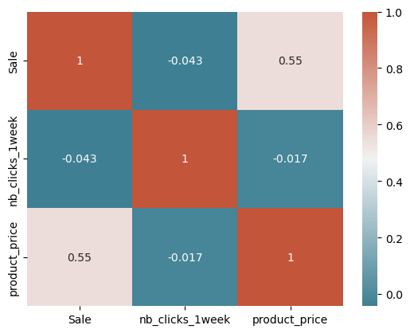

```python
corr = df_exp.corr()
sns.heatmap(corr, xticklabels=corr.columns, yticklabels=corr.columns,
            annot=True, cmap=sns.diverging_palette(220, 20, as_cmap=True))
```

Porównanie par zmiennych na osobnych wykresach.

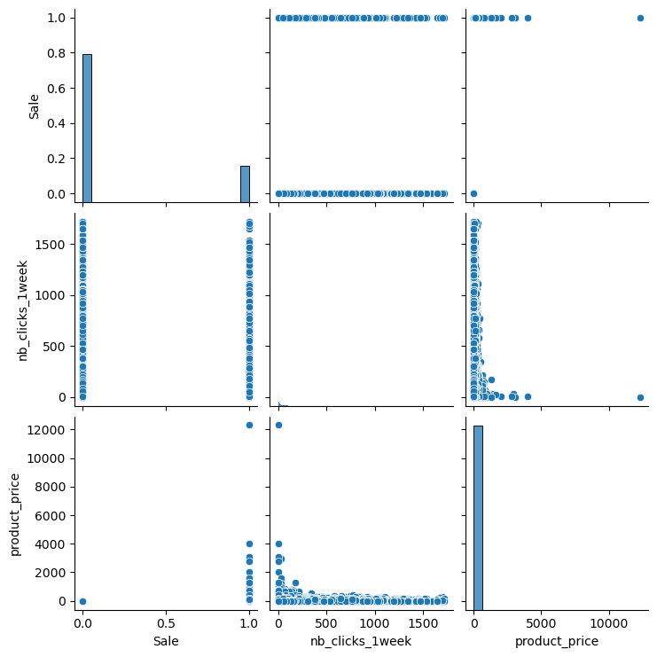

```python
sns.pairplot(df_exp)
```

Jak można zauważyć występuje dosyć silna korelacja między sprzedażą produktu, a jego ceną. Sprawdźmy jak będzie wyglądać ta para na wykresie punktowym.

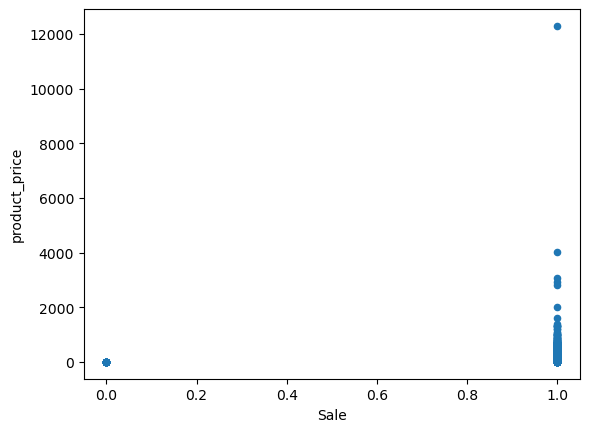

```python
df_exp.plot(kind='scatter', x='Sale', y='product_price')
```

Korelacja jest widoczna:

- Kiedy sprzedaż nie wystąpiła - cena naturalnie wynosi 0
- Kiedy sprzedaż nastąpiła - wszystkie wartości cen produktu wpadają do jednej linii na osi Y, przy wartości sprzedaży 1.

Sprawdźmy jak wygląda dystrybucja tej pary danych na histogramie. Najpierw wyczyśćmy jednak dataset z linii bez sprzedanych produktów.

```python
df_exp_sold = df_exp[df_exp['Sale'] == 1]
df_exp_sold.describe()
```

|  | Sale | nb_clicks_1week | product_price |
| --- | --- | --- | --- |
| count | 46706.0 | 46706.000000 | 46706.000000 |
| mean | 1.0 | 42.480880 | 71.190425 |
| std | 0.0 | 123.511805 | 97.310524 |
| min | 1.0 | -1.000000 | 0.010000 |
| 25% | 1.0 | 1.000000 | 27.730000 |
| 50% | 1.0 | 7.000000 | 45.000000 |
| 75% | 1.0 | 30.000000 | 89.990000 |
| max | 1.0 | 1724.000000 | 12300.000000 |

Z racji na duży ogon cen produktu, musimy ustalić granicę, od której usuwamy outliery.

Zwizualizujmy dane na boxplocie.

[figure not shown]

```python
sns.boxplot(x=df_exp_sold['product_price'], width=10)
```

Jako przedziały wybieram przedziały wąsów boxplota (dolna = max(0, Q1 - 1.5 IQR), górna = Q3 + 1.5 IQR) Ustalam także ilość przedziałów i ich szerokość.

```python
price_75th = df_exp_sold['product_price'].quantile(0.75)
price_25th = df_exp_sold['product_price'].quantile(0.25)
price_iqr = price_75th - price_25th
upper = price_75th + (1.5 * price_iqr)
lower = price_25th - (1.5 * price_iqr)
print(price_iqr)
print(upper)
print(lower)

bin_number = int(1 + 3.322 * np.log(len(df_exp_sold)))
print(bin_number)

bin_size = int(2 * price_iqr * pow(len(df_exp_sold), -1/3))
print(bin_size)
```

```
62.25999999999999
183.38
-65.65999999999998
36
3
```

```python
df_exp_sold = df_exp_sold[df_exp_sold['product_price'].between(max(lower, 0), upper)]
df_exp_sold.describe()
```

|  | Sale | nb_clicks_1week | product_price |
| --- | --- | --- | --- |
| count | 43532.0 | 43532.000000 | 43532.000000 |
| mean | 1.0 | 41.740605 | 56.345246 |
| std | 0.0 | 122.236100 | 41.233228 |
| min | 1.0 | -1.000000 | 0.010000 |
| 25% | 1.0 | 1.000000 | 25.990000 |
| 50% | 1.0 | 7.000000 | 41.000000 |
| 75% | 1.0 | 29.000000 | 79.000000 |
| max | 1.0 | 1724.000000 | 183.000000 |

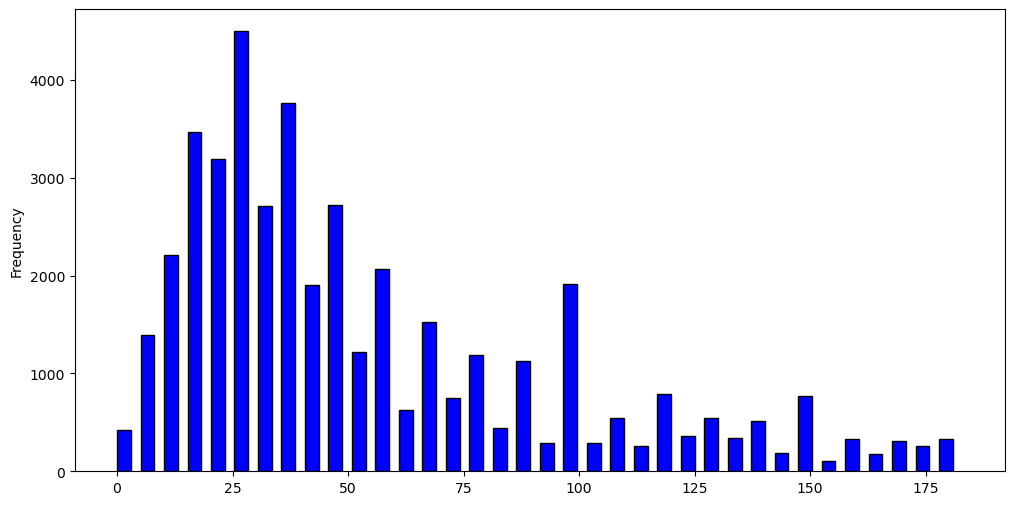

```python
df_exp_sold['product_price'].plot(kind='hist', bins=bin_number, figsize=(12, 6),
                             width=bin_size, facecolor='blue', edgecolor='black')
```

Szeregi rozdzielcze dla wybranych zmiennych.

```python
df_exp_freq = []
for i in df_exp_sold.columns:
    df_i = pd.DataFrame()
    df_i.index.name = str(i)
    df_i['Count'] = df_exp_sold[i].value_counts()
    df_i['Frequency'] = df_exp_sold[i].value_counts() / sum(df_exp[i].value_counts())
    print(df_i)
    print('------------------------------------------')
```

```
      Count  Frequency
Sale
1     43532   0.185063
------------------------------------------
                 Count  Frequency
nb_clicks_1week
0                 8517   0.036207
1                 3921   0.016669
2                 2741   0.011653
3                 2089   0.008881
4                 1592   0.006768
...                ...        ...
525                  1   0.000004
746                  1   0.000004
692                  1   0.000004
313                  1   0.000004
768                  1   0.000004

[648 rows x 2 columns]
------------------------------------------
               Count  Frequency
product_price
29.99           1845   0.007843
39.99           1537   0.006534
49.99           1369   0.005820
19.99           1183   0.005029
34.99           1108   0.004710
...              ...        ...
31.13              1   0.000004
101.25             1   0.000004
51.30              1   0.000004
98.55              1   0.000004
15.50              1   0.000004

[1335 rows x 2 columns]
------------------------------------------
                                  Count  Frequency
product_age_group
4C90FD52FC53D2C1C205844CB69575AB  42847   0.182151
88460293E9517D21E39AA889BD5AADC8    454   0.001930
```

[output cut: 33 more lines]

```
product_brand
53F02588B177AA9BA649AC9C091F44D4   2639   0.011219
6C0F874E8CD1A6F748737B6B5CB057F5   2555   0.010862
A51459F2008EB80D460C2463096349D8   2423   0.010301
E15F861F6390FAC60799ACA9F596BC58   2115   0.008991
C153E8F0FBDDA2D14CC066665B07AE35   2046   0.008698
...                                 ...        ...
F6D410E970AB18CF3F21002D99F5D18F      1   0.000004
AF10539679D6244A32F54C08D4DF21CE      1   0.000004
A9A439FBD9DCCB67DD3226B309641599      1   0.000004
DB56DA90A5D0C009AFC95057511CD3B9      1   0.000004
B6AE3E0D9D887FBF4794C28697E5C8CC      1   0.000004

[387 rows x 2 columns]
------------------------------------------
```

# TEST STATYSTYCZNY

Hipoteza zerowa H0: Marki z pierwszej 5 najczęściej sprzedawanych produktów nie mają żadnego wpływu na stosunek ilości sprzedaży do wyświetleń produktu. (H0: p = p0) Hipoteza alternatywna H1: Marki (product_brand) z pierwszej 5 najczęściej sprzedanych produktów znacznie różnią się stosunkiem ilości sprzedaży do wyświetleń produktu. (H1: p != p0) Poziom istotności Alfa = 0.05.

```python
df_exp = df_exp[df_exp['product_brand'] != '-1']
df_exp_not_sold = df_exp[df_exp['Sale'] == 0]
```

Stwórzmy subset zawierający liczbę sprzedaży dla danej marki produktu (product_brand).

```python
# df_sub = df_exp.groupby(['product_brand', 'Sale']).size()
df_exp.dropna(axis='rows')
df_sub = pd.crosstab(df_exp['product_brand'], np.where(df_exp['Sale'] == 0, 'View_count', 'Sale_count')).reset_index()
df_sub['Sale_View_ratio'] = df_sub['Sale_count'] / (df_sub['View_count'] + df_sub['Sale_count'])
df_sub.replace(np.inf, 0, inplace=True)

df_sub.describe()
```

| col_0 | Sale_count | View_count | Sale_View_ratio |
| --- | --- | --- | --- |
| count | 436.000000 | 436.000000 | 436.000000 |
| mean | 106.612385 | 428.791284 | 0.200150 |
| std | 334.938016 | 1361.557546 | 0.139339 |
| min | 0.000000 | 0.000000 | 0.000000 |
| 25% | 2.000000 | 10.000000 | 0.133333 |
| 50% | 15.500000 | 62.000000 | 0.192927 |
| 75% | 71.500000 | 307.500000 | 0.250000 |
| max | 2894.000000 | 11820.000000 | 1.000000 |

Obliczmy wszystkie potrzebne statystyki dla populacji

```python
sale_count = df_sub.Sale_count.sum()
view_count = df_sub.View_count.sum() + df_sub.Sale_count.sum()
sale_view_ratio = df_sub.Sale_count.sum() / (df_sub.Sale_count.sum() + df_sub.View_count.sum())
sale_mean = np.mean(df_sub['Sale_count'])
sale_median = np.median(df_sub['Sale_count'])
sale_std = np.std(df_sub['Sale_count'])
# df_sub.rename(columns={0: 'product_brand'}, inplace=True)
print("Statystyki populacji:\n")
print("Liczba sprzedaży: {}\n".format(sale_count))
print("Liczba wyświetleń: {}\n".format(view_count))
print("Sale/View ratio: {}%\n".format(round(100 * sale_view_ratio, 3)))
print("Średnia ilość sprzedaży produktu: {}\n".format(round(sale_mean)))
print("Mediana sprzedaży produktu: {}\n".format(round(sale_median)))
print("Odchylenie standardowe sprzedaży produktu: {}\n".format(round(sale_std)))
pop_skew = df_sub.skew(axis=0, skipna=True)
print("Skośność populacji: {}\n".format(pop_skew))
pop_kurt = df_sub.kurt(axis=0)
print("Kurtoza populacji: {}\n".format(pop_kurt))
```

```
Statystyki populacji:

Liczba sprzedaży: 46483

Liczba wyświetleń: 233436

Sale/View ratio: 19.913%

Średnia ilość sprzedaży produktu: 107

Mediana sprzedaży produktu: 16

Odchylenie standardowe sprzedaży produktu: 335

Skośność populacji: col_0
Sale_count         6.059321
View_count         6.031836
Sale_View_ratio    2.184518
dtype: float64

Kurtoza populacji: col_0
Sale_count         40.367787
View_count         39.562481
Sale_View_ratio     9.951462
dtype: float64
```

Zbadajmy rozkład populacji

```python
price_75th = df_sub['Sale_View_ratio'].quantile(0.75)
price_25th = df_sub['Sale_View_ratio'].quantile(0.25)
price_iqr = price_75th - price_25th
upper = price_75th + (1.5 * price_iqr)
lower = price_25th - (1.5 * price_iqr)
# print(price_iqr)
# print(upper)
# print(lower)
bin_number = int(1 + 3.322 * np.log(len(df_sub)))
print(bin_number)
bin_size = (2 * price_iqr * pow(len(df_sub), -1/3))
print(bin_size)
# print(df_sub.sort_values('Sale_View_ratio', ascending=False))
```

```
21
0.030771449586023104
```

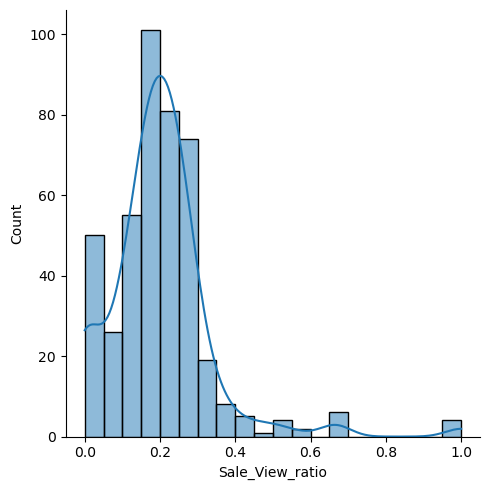

```python
sns.displot(data=df_sub, x='Sale_View_ratio', kde=True,
             binwidth=0.05)
```

Statystyki dla próby

```python
n = 5
top_5 = df_sub.sort_values('Sale_count', ascending=False).nlargest(n, 'Sale_count')
top_5_sold = []
top_5_sold_view  = []
top_5_brands = []

for i in range(n):
    most_sold_brands = str(top_5['product_brand'].values[i])
    top_5_brands.append(most_sold_brands)

for i in top_5_brands:
    top_5_all = df_sub.loc[df_sub['product_brand'] == i, 'View_count'].iloc[0]
    top_5_sold_view.append(top_5_all)
    top_5_all = df_sub.loc[df_sub['product_brand'] == i, 'Sale_count'].iloc[0]
    top_5_sold.append(top_5_all)

print(top_5)
print("\n\n")
print(top_5.describe())
```

```
col_0                     product_brand  Sale_count  View_count  \
180    6C0F874E8CD1A6F748737B6B5CB057F5        2894       10848
142    53F02588B177AA9BA649AC9C091F44D4        2734       10072
265    A51459F2008EB80D460C2463096349D8        2722       11820
378    E15F861F6390FAC60799ACA9F596BC58        2498        9713
317    C153E8F0FBDDA2D14CC066665B07AE35        2167       10238

col_0  Sale_View_ratio
180           0.210595
142           0.213494
265           0.187182
378           0.204570
317           0.174688



col_0   Sale_count    View_count  Sale_View_ratio
count     5.000000      5.000000         5.000000
mean   2603.000000  10538.200000         0.198106
std     281.568819    825.742817         0.016600
min    2167.000000   9713.000000         0.174688
25%    2498.000000  10072.000000         0.187182
50%    2722.000000  10238.000000         0.204570
75%    2734.000000  10848.000000         0.210595
max    2894.000000  11820.000000         0.213494
```

```python
top_5_sale_count = top_5.Sale_count.sum()
top_5_view_count = top_5.View_count.sum() + top_5.Sale_count.sum()
top_5_sale_view_ratio = top_5.Sale_count.sum() / (top_5.Sale_count.sum() + top_5.View_count.sum())
top_5_sale_mean = np.mean(top_5['Sale_count'])
top_5_sale_median = np.median(top_5['Sale_count'])
top_5_sale_std = np.std(top_5['Sale_count'])

print("Statystyki próby:\n")
print("Liczba sprzedaży: {}\n".format(top_5_sale_count))
print("Liczba wyświetleń: {}\n".format(top_5_view_count))
print("Sale/View ratio: {}%\n".format(round(100 * top_5_sale_view_ratio, 3)))
print("Średnia ilość sprzedaży produktu: {}\n".format(round(top_5_sale_mean)))
print("Mediana sprzedaży produktu: {}\n".format(round(top_5_sale_median)))
print("Odchylenie standardowe sprzedaży produktu: {}\n".format(round(top_5_sale_std)))
pop_skew = top_5.skew(axis=0, skipna=True)
print("Skośność populacji: {}\n".format(pop_skew))
pop_kurt = top_5.kurt(axis=0)
print("Kurtoza populacji: {}\n".format(pop_kurt))
```

```
Statystyki próby:

Liczba sprzedaży: 13015

Liczba wyświetleń: 65706

Sale/View ratio: 19.808%

Średnia ilość sprzedaży produktu: 2603

Mediana sprzedaży produktu: 2722

Odchylenie standardowe sprzedaży produktu: 252

Skośność populacji: col_0
Sale_count        -1.035254
View_count         1.069683
Sale_View_ratio   -0.754510
dtype: float64

Kurtoza populacji: col_0
Sale_count         0.735205
View_count         0.678238
Sale_View_ratio   -1.463115
dtype: float64
```

```python
price_75th = top_5['Sale_View_ratio'].quantile(0.75)
price_25th = top_5['Sale_View_ratio'].quantile(0.25)
price_iqr = price_75th - price_25th
upper = price_75th + (1.5 * price_iqr)
lower = price_25th - (1.5 * price_iqr)
# print(price_iqr)
# print(upper)
# print(lower)
bin_number = int(1 + 3.322 * np.log(len(top_5)))
print(bin_number)
bin_size = (2 * price_iqr * pow(len(top_5), -1/3))
print(bin_size)
```

```
6
0.02738436146117394
```

Zbadajmy rozkład próbki

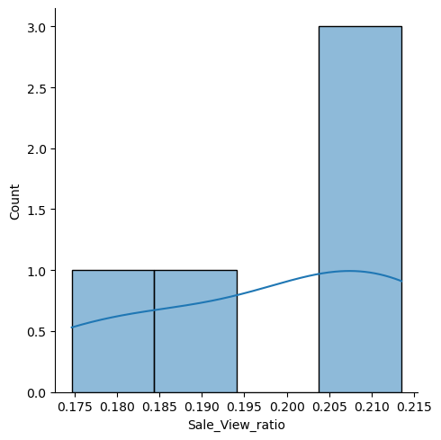

```python
sns.displot(data=top_5, x='Sale_View_ratio', kde=True)
```

Wykonamy teraz test z dla proporcji.

```python
def z_test(sample_proportion, h0_proportion, sample_size):
    z = (sample_proportion - h0_proportion) \
        / np.sqrt((h0_proportion * (1 - h0_proportion)) / sample_size)

    return z
```

```python
z_score = z_test(top_5_sale_view_ratio, sale_view_ratio,
                          top_5_view_count + top_5_sale_count)
print("Wartość statystyki testowej Z: {}\n".
      format(round(z_score, 3)))
```

```
Wartość statystyki testowej Z: -0.735
```

```python
import scipy.stats as st
alpha = 0.05
print("Z krytyczne dla testu dwustronnego: <-inf, -{}> v <{}, inf>\n".format(round(st.norm.ppf(1 - alpha / 2), 3),
                                                              round(st.norm.ppf(1 - alpha / 2), 3)))
```

```
Z krytyczne dla testu dwustronnego: <-inf, -1.96> v <1.96, inf>
```

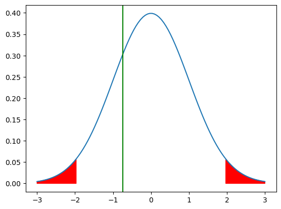

```python
mu = 0
var = 1
s = np.sqrt(var)
x = np.linspace(mu - 3 * s, mu + 3 * s, 100)
density_curve = st.norm.pdf(x, mu, s)
plt.plot(x, density_curve)
lx = np.arange(-3, -1.96, 10)
px = np.arange(1.96, 3, 10)
plt.fill_between(x, density_curve, color='r', where=(x < -1.96) | (x > 1.96))
plt.axvline(x=z_score, color='g')
plt.show()
```

Jako, że wartość statystyki testowej Z nie zawiera się w przedziałach Z-krytycznego, nie ma podstaw do odrzucenia hipotezy zerowej H0:

# Inżynieria cech

Przyjrzyjmy się jeszcze raz pełnemu datasetowi

```python
df.head()
```

|  | Sale | SalesAmountInEuro | time_delay_for_conversion | click_timestamp | nb_clicks_1week | product_price | product_age_group | device_type | audience_id | product_gender | ... | product_category(3) | product_category(4) | product_category(5) | product_category(6) | product_category(7) | product_country | product_id | product_title | partner_id | user_id |
| --- | --- | --- | --- | --- | --- | --- | --- | --- | --- | --- | --- | --- | --- | --- | --- | --- | --- | --- | --- | --- | --- |
| 0 | 0 | -1.00000 | -1 | 1601437273 | 6 | 0.00 | 4C90FD52FC53D2C1C205844CB69575AB | D7D1FB49049702BF6338894757E0D959 | -1 | A5D15FC386510762EC0DDFF54ABE6F94 | ... | 8A30BF8BD2B3E9D44D2938D42C387D2E | -1 | -1 | -1 | -1 | 2AC62132FBCFA093B9426894A4BC6278 | 77AEF49D383E58FA384E99C177BF62D6 | F0F9816E146A3DF9B8A99B3B12A77362 922FACDC63DBA... | 9FF550C0B17A3C493378CB6E2DEEE6E4 | BB3F8CAD8C5AAF88CD7BE8C6FC356A2D |
| 1 | 0 | -1.00000 | -1 | 1601384595 | 14 | 0.00 | 4C90FD52FC53D2C1C205844CB69575AB | FF2C446555E3822B0E0FC3406116E86D | 13F966B23C28D8A8FECAFC2FC2CD7E00 | A5D15FC386510762EC0DDFF54ABE6F94 | ... | 2E4ED2B95CEF7FD11B282CDFDD56CEA0 | -1 | -1 | -1 | -1 | 2AC62132FBCFA093B9426894A4BC6278 | 3D55D8AEBBDAA58EB5FAA244601242D3 | 777BEECAD173AC93E5CE0CE1CC82DF15 65C0CABE6A2B2... | 9FF550C0B17A3C493378CB6E2DEEE6E4 | 8275B52D8FD8CBDA13BC2B36F110856C |
| 2 | 0 | -1.00000 | -1 | 1601369627 | 5 | 0.00 | 4C90FD52FC53D2C1C205844CB69575AB | FF2C446555E3822B0E0FC3406116E86D | -1 | A5D15FC386510762EC0DDFF54ABE6F94 | ... | 0279CBF3081FFB710CE52B9E0BA4AABF | 35A13FB2AB63E920B7D71C5957131606 | -1 | -1 | -1 | 2AC62132FBCFA093B9426894A4BC6278 | FADA68550BC65EF5F94718C02E437AA8 | C1B4729F10A2EA1402FBFB449E38825F 078EE401D7044... | 9FF550C0B17A3C493378CB6E2DEEE6E4 | 63D63E591416C1DD1EA80474EFD36E99 |
| 3 | 1 | 91.61788 | 619 | 1601422663 | 8 | 107.99 | 4C90FD52FC53D2C1C205844CB69575AB | D7D1FB49049702BF6338894757E0D959 | F432D202376506262B3F24AD1D565D4F | A5D15FC386510762EC0DDFF54ABE6F94 | ... | 0279CBF3081FFB710CE52B9E0BA4AABF | 35A13FB2AB63E920B7D71C5957131606 | -1 | -1 | -1 | 2AC62132FBCFA093B9426894A4BC6278 | 4EB3BA0A95DCD9C6B9906C160C7FE4BD | C1B4729F10A2EA1402FBFB449E38825F 078EE401D7044... | 9FF550C0B17A3C493378CB6E2DEEE6E4 | 1CFBA4098ABC71751ECEEDFE2D59BE4D |
| 4 | 1 | 23.79454 | 1855650 | 1601377189 | 23 | 13.99 | 4C90FD52FC53D2C1C205844CB69575AB | FF2C446555E3822B0E0FC3406116E86D | 32B8ABA7E55F4BB8356338F743EA37AF | A5D15FC386510762EC0DDFF54ABE6F94 | ... | C08050B58F54FA81F4580ECE15296698 | 067525A83E1875CB1828F4F9ADC752F6 | -1 | -1 | -1 | 2AC62132FBCFA093B9426894A4BC6278 | 5EAD3217B11B8F3DFF3403453E9A53AD | 4BCB07CC282329F41EF71E62693EBDAA 08DE6267A8660... | 9FF550C0B17A3C493378CB6E2DEEE6E4 | 692FB9599DAB1062AC09F218323CAB25 |

5 rows × 23 columns

```python
df.select_dtypes(include='object')
```

|  | product_age_group | device_type | audience_id | product_gender | product_brand | product_category(1) | product_category(2) | product_category(3) | product_category(4) | product_category(5) | product_category(6) | product_country | product_id | product_title | partner_id | user_id |
| --- | --- | --- | --- | --- | --- | --- | --- | --- | --- | --- | --- | --- | --- | --- | --- | --- |
| 0 | 4C90FD52FC53D2C1C205844CB69575AB | D7D1FB49049702BF6338894757E0D959 | -1 | A5D15FC386510762EC0DDFF54ABE6F94 | 635A3EF4F16C9B52F3334F52B864E056 | 033E492229C2222EFAA16EE8A6462D8B | 77FFC91A6157E50A0A114135F18BB1DB | 8A30BF8BD2B3E9D44D2938D42C387D2E | -1 | -1 | -1 | 2AC62132FBCFA093B9426894A4BC6278 | 77AEF49D383E58FA384E99C177BF62D6 | F0F9816E146A3DF9B8A99B3B12A77362 922FACDC63DBA... | 9FF550C0B17A3C493378CB6E2DEEE6E4 | BB3F8CAD8C5AAF88CD7BE8C6FC356A2D |
| 1 | 4C90FD52FC53D2C1C205844CB69575AB | FF2C446555E3822B0E0FC3406116E86D | 13F966B23C28D8A8FECAFC2FC2CD7E00 | A5D15FC386510762EC0DDFF54ABE6F94 | 777BEECAD173AC93E5CE0CE1CC82DF15 | 033E492229C2222EFAA16EE8A6462D8B | 77FFC91A6157E50A0A114135F18BB1DB | 2E4ED2B95CEF7FD11B282CDFDD56CEA0 | -1 | -1 | -1 | 2AC62132FBCFA093B9426894A4BC6278 | 3D55D8AEBBDAA58EB5FAA244601242D3 | 777BEECAD173AC93E5CE0CE1CC82DF15 65C0CABE6A2B2... | 9FF550C0B17A3C493378CB6E2DEEE6E4 | 8275B52D8FD8CBDA13BC2B36F110856C |
| 2 | 4C90FD52FC53D2C1C205844CB69575AB | FF2C446555E3822B0E0FC3406116E86D | -1 | A5D15FC386510762EC0DDFF54ABE6F94 | 53F02588B177AA9BA649AC9C091F44D4 | 7F286560861764CCB93C90B7AA833949 | 891EE660A73D9A6E1F4BD6149E613C44 | 0279CBF3081FFB710CE52B9E0BA4AABF | 35A13FB2AB63E920B7D71C5957131606 | -1 | -1 | 2AC62132FBCFA093B9426894A4BC6278 | FADA68550BC65EF5F94718C02E437AA8 | C1B4729F10A2EA1402FBFB449E38825F 078EE401D7044... | 9FF550C0B17A3C493378CB6E2DEEE6E4 | 63D63E591416C1DD1EA80474EFD36E99 |
| 3 | 4C90FD52FC53D2C1C205844CB69575AB | D7D1FB49049702BF6338894757E0D959 | F432D202376506262B3F24AD1D565D4F | A5D15FC386510762EC0DDFF54ABE6F94 | 53F02588B177AA9BA649AC9C091F44D4 | 7F286560861764CCB93C90B7AA833949 | 891EE660A73D9A6E1F4BD6149E613C44 | 0279CBF3081FFB710CE52B9E0BA4AABF | 35A13FB2AB63E920B7D71C5957131606 | -1 | -1 | 2AC62132FBCFA093B9426894A4BC6278 | 4EB3BA0A95DCD9C6B9906C160C7FE4BD | C1B4729F10A2EA1402FBFB449E38825F 078EE401D7044... | 9FF550C0B17A3C493378CB6E2DEEE6E4 | 1CFBA4098ABC71751ECEEDFE2D59BE4D |
| 4 | 4C90FD52FC53D2C1C205844CB69575AB | FF2C446555E3822B0E0FC3406116E86D | 32B8ABA7E55F4BB8356338F743EA37AF | A5D15FC386510762EC0DDFF54ABE6F94 | 6271E7ACEF710C0C57E758E473279B63 | 033E492229C2222EFAA16EE8A6462D8B | 77FFC91A6157E50A0A114135F18BB1DB | C08050B58F54FA81F4580ECE15296698 | 067525A83E1875CB1828F4F9ADC752F6 | -1 | -1 | 2AC62132FBCFA093B9426894A4BC6278 | 5EAD3217B11B8F3DFF3403453E9A53AD | 4BCB07CC282329F41EF71E62693EBDAA 08DE6267A8660... | 9FF550C0B17A3C493378CB6E2DEEE6E4 | 692FB9599DAB1062AC09F218323CAB25 |
| ... | ... | ... | ... | ... | ... | ... | ... | ... | ... | ... | ... | ... | ... | ... | ... | ... |
| 235223 | 4C90FD52FC53D2C1C205844CB69575AB | D7D1FB49049702BF6338894757E0D959 | 64C38997693B03EF7B1D3EC451614074 | A5D15FC386510762EC0DDFF54ABE6F94 | 9D3F6123D731D0CBB0D98B0E2BD7AD3C | 7F286560861764CCB93C90B7AA833949 | 891EE660A73D9A6E1F4BD6149E613C44 | 0279CBF3081FFB710CE52B9E0BA4AABF | 00156DF500074D05CDE9DB45DB64347F | -1 | -1 | 2AC62132FBCFA093B9426894A4BC6278 | 6C60BD4EB31D2993C9B1AA75B268D1FD | 9D3F6123D731D0CBB0D98B0E2BD7AD3C E935402728890... | 9FF550C0B17A3C493378CB6E2DEEE6E4 | 0A16B236ED49D1493725C6DC59E57EFC |
| 235224 | 4C90FD52FC53D2C1C205844CB69575AB | D7D1FB49049702BF6338894757E0D959 | -1 | A5D15FC386510762EC0DDFF54ABE6F94 | EE3682F6BA3A90CD9556559A2086369E | 13C26D10258053889D75D9B9CA922EC7 | 346AC0DECB71FFDC9114236B419D7814 | 864413AC3D577057CD559822EB6700BC | A734AD20DF4C75436D26FB98749F40B9 | -1 | -1 | 2AC62132FBCFA093B9426894A4BC6278 | 4EA4DC291D19E1C112A68AF1E885D465 | EE3682F6BA3A90CD9556559A2086369E E51D5D0CB9C56... | 9FF550C0B17A3C493378CB6E2DEEE6E4 | CC25D9D1CC242401475798E9BB9BE224 |
| 235225 | 4C90FD52FC53D2C1C205844CB69575AB | D7D1FB49049702BF6338894757E0D959 | -1 | A5D15FC386510762EC0DDFF54ABE6F94 | F19FAAE9EE2976EC66B9D76A5C73B0DC | 7F286560861764CCB93C90B7AA833949 | BB4A179E615AD18488A859BC09B06D60 | 7044EBFB6C2F2090C90798471AB9E932 | -1 | -1 | -1 | 2AC62132FBCFA093B9426894A4BC6278 | DB63E33F6C5EB055C0D05DA61F63BD95 | F19FAAE9EE2976EC66B9D76A5C73B0DC 3B009DBA3E942... | 9FF550C0B17A3C493378CB6E2DEEE6E4 | 1801953F7E9640A2FC3BF52CC8F8DD61 |
| 235226 | 4C90FD52FC53D2C1C205844CB69575AB | D7D1FB49049702BF6338894757E0D959 | -1 | C45A9AC6D102ACAEEDF0D6F78636D84A | A51459F2008EB80D460C2463096349D8 | 033E492229C2222EFAA16EE8A6462D8B | 77FFC91A6157E50A0A114135F18BB1DB | C08050B58F54FA81F4580ECE15296698 | 067525A83E1875CB1828F4F9ADC752F6 | -1 | -1 | 2AC62132FBCFA093B9426894A4BC6278 | 24752C77BA77193B3447169B494DC148 | 2C1610F803F76AD407DE7B0B46928D98 9E602BFCC65B8... | 9FF550C0B17A3C493378CB6E2DEEE6E4 | C0AAC85338B54610673F9FA98B5945E3 |
| 235227 | 4C90FD52FC53D2C1C205844CB69575AB | D7D1FB49049702BF6338894757E0D959 | -1 | A5D15FC386510762EC0DDFF54ABE6F94 | E15F861F6390FAC60799ACA9F596BC58 | 033E492229C2222EFAA16EE8A6462D8B | 77FFC91A6157E50A0A114135F18BB1DB | E5E65C3A7E932E54963A72C6F0BF1B71 | 9A4E199A31E4A7B6CE84FBA8C02D88D2 | -1 | -1 | 2AC62132FBCFA093B9426894A4BC6278 | 1498978AC061FBA39353EF1592E9887F | D314501C832BBB40B926BCFC2510EE72 17C1AE137BA1A... | 9FF550C0B17A3C493378CB6E2DEEE6E4 | 563FBB917EE8863CBD6E400C0D69ADD6 |

235228 rows × 16 columns

```python
df_cleared = df
df_cleared[df_cleared.select_dtypes(include='object').columns] = df_cleared[df_cleared.select_dtypes(include='object').columns].replace('-1', 'None')
df_cleared = df_cleared.drop(['product_category(7)'], axis=1)
# df_cleared = df_cleared.dropna(thresh=df.shape[0]*0.4, axis=1)
#df_cleared = df_cleared.dropna(thresh=[], axis=0)
df_cleared.info()
df_cleared = df_cleared.dropna(how='any')
df_cleared.info()
```

```
<class 'pandas.core.frame.DataFrame'>
RangeIndex: 235228 entries, 0 to 235227
Data columns (total 22 columns):
 #   Column                     Non-Null Count   Dtype
---  ------                     --------------   -----
 0   Sale                       235228 non-null  int64
 1   SalesAmountInEuro          235228 non-null  float64
 2   time_delay_for_conversion  235228 non-null  int64
 3   click_timestamp            235228 non-null  int64
 4   nb_clicks_1week            235228 non-null  int64
 5   product_price              235228 non-null  float64
 6   product_age_group          235228 non-null  object
 7   device_type                235228 non-null  object
 8   audience_id                235228 non-null  object
 9   product_gender             235228 non-null  object
```

[output cut: 43 more lines]

Zamieńmy kolumnę click_timestamp na type datetime.

```python
from datetime import datetime
df_cleared['click_timestamp'] = pd.to_datetime(df_cleared['click_timestamp'], unit='s')
df_cleared.sort_values('click_timestamp')
```

|  | Sale | SalesAmountInEuro | time_delay_for_conversion | click_timestamp | nb_clicks_1week | product_price | product_age_group | device_type | audience_id | product_gender | ... | product_category(2) | product_category(3) | product_category(4) | product_category(5) | product_category(6) | product_country | product_id | product_title | partner_id | user_id |
| --- | --- | --- | --- | --- | --- | --- | --- | --- | --- | --- | --- | --- | --- | --- | --- | --- | --- | --- | --- | --- | --- |
| 210193 | 0 | -1.00000 | -1 | 2020-08-03 07:25:30 | 3 | 0.00 | 4C90FD52FC53D2C1C205844CB69575AB | 7E56C27BFF0305E788DA55A029EC4988 | None | A5D15FC386510762EC0DDFF54ABE6F94 | ... | 891EE660A73D9A6E1F4BD6149E613C44 | 0279CBF3081FFB710CE52B9E0BA4AABF | 64868C215977B4DCC3342FD091F55A87 | None | None | 2AC62132FBCFA093B9426894A4BC6278 | DFF67AA1152442A5E90E4D74D4DF3A18 | C1B4729F10A2EA1402FBFB449E38825F 078EE401D7044... | 9FF550C0B17A3C493378CB6E2DEEE6E4 | 7C674AB24A17D61614F826EE6BD68732 |
| 225335 | 0 | -1.00000 | -1 | 2020-08-03 07:26:52 | 20 | 0.00 | 4C90FD52FC53D2C1C205844CB69575AB | D7D1FB49049702BF6338894757E0D959 | None | A5D15FC386510762EC0DDFF54ABE6F94 | ... | 891EE660A73D9A6E1F4BD6149E613C44 | 0279CBF3081FFB710CE52B9E0BA4AABF | 35A13FB2AB63E920B7D71C5957131606 | None | None | 2AC62132FBCFA093B9426894A4BC6278 | AE12E254F06DBE2F626E9A78853CF1AB | 5E4C83186D38396CB17630624467B7A1 2D55AF3396FDB... | 9FF550C0B17A3C493378CB6E2DEEE6E4 | D961A8C95C9A262E39BE94D10E06D0B0 |
| 225359 | 0 | -1.00000 | -1 | 2020-08-03 07:30:21 | 64 | 0.00 | 4C90FD52FC53D2C1C205844CB69575AB | FF2C446555E3822B0E0FC3406116E86D | None | A5D15FC386510762EC0DDFF54ABE6F94 | ... | 891EE660A73D9A6E1F4BD6149E613C44 | 0279CBF3081FFB710CE52B9E0BA4AABF | 35A13FB2AB63E920B7D71C5957131606 | None | None | 2AC62132FBCFA093B9426894A4BC6278 | B9B840E663ADE6772E10027EB3BCA4ED | 06ECC41D424C18F0F4C7159498C2517B 1C9A2EDB98AA4... | 9FF550C0B17A3C493378CB6E2DEEE6E4 | 4CFE98C96827C311ABD2846BA90C81DD |
| 234000 | 1 | 166.22050 | 726 | 2020-08-03 07:32:58 | 0 | 74.97 | 4C90FD52FC53D2C1C205844CB69575AB | 7E56C27BFF0305E788DA55A029EC4988 | None | A5D15FC386510762EC0DDFF54ABE6F94 | ... | 891EE660A73D9A6E1F4BD6149E613C44 | 0279CBF3081FFB710CE52B9E0BA4AABF | 00156DF500074D05CDE9DB45DB64347F | None | None | 2AC62132FBCFA093B9426894A4BC6278 | E99183FF6F59E5F38E9FDBF1143B705F | 9238E14F5141789621B0D0507741CFCF 1D4D8C52654EF... | 9FF550C0B17A3C493378CB6E2DEEE6E4 | B75C9633A3628AF93C836EF9E4B0FFA7 |
| 116269 | 0 | -1.00000 | -1 | 2020-08-03 07:33:53 | 12 | 0.00 | 4C90FD52FC53D2C1C205844CB69575AB | 7E56C27BFF0305E788DA55A029EC4988 | 17F20B29B2A3D5ACEB7F5CF6385DBD02 | A5D15FC386510762EC0DDFF54ABE6F94 | ... | 891EE660A73D9A6E1F4BD6149E613C44 | 755FCFBCC31578C16D48289ED6830BF5 | 49CF3B8E55E28D83E7AD481AD0A8A7D9 | None | None | 2AC62132FBCFA093B9426894A4BC6278 | 61E9A38B46501ADF2BB0EB88A8FEC927 | C1B4729F10A2EA1402FBFB449E38825F 078EE401D7044... | 9FF550C0B17A3C493378CB6E2DEEE6E4 | 42BA4DFD7726FFDED9A7938F90E4944B |
| ... | ... | ... | ... | ... | ... | ... | ... | ... | ... | ... | ... | ... | ... | ... | ... | ... | ... | ... | ... | ... | ... |
| 153048 | 0 | -1.00000 | -1 | 2020-11-02 07:22:38 | 16 | 0.00 | 4C90FD52FC53D2C1C205844CB69575AB | D7D1FB49049702BF6338894757E0D959 | None | C45A9AC6D102ACAEEDF0D6F78636D84A | ... | 77FFC91A6157E50A0A114135F18BB1DB | 2424569621EB2CC03C58D73EB9AF3717 | None | None | None | 2AC62132FBCFA093B9426894A4BC6278 | 14BA8BB88277A532192B61474B3F2BFA | 2C1610F803F76AD407DE7B0B46928D98 9E602BFCC65B8... | 9FF550C0B17A3C493378CB6E2DEEE6E4 | EB371248D1F6E47F3BC52D33EF836115 |
| 15776 | 0 | -1.00000 | -1 | 2020-11-02 07:22:56 | 50 | 0.00 | 4C90FD52FC53D2C1C205844CB69575AB | 7E56C27BFF0305E788DA55A029EC4988 | None | C45A9AC6D102ACAEEDF0D6F78636D84A | ... | 77FFC91A6157E50A0A114135F18BB1DB | C08050B58F54FA81F4580ECE15296698 | 067525A83E1875CB1828F4F9ADC752F6 | None | None | 2AC62132FBCFA093B9426894A4BC6278 | FA2550549B17EFC5EB89CA2A5D2D3CD7 | 59F24E189613FCC1CB8815AF56700ACF F2925DB57354E... | 9FF550C0B17A3C493378CB6E2DEEE6E4 | 5EC4748014416CAC3A8F1AAB44E9A6F3 |
| 153028 | 0 | -1.00000 | -1 | 2020-11-02 07:23:38 | 30 | 0.00 | 4C90FD52FC53D2C1C205844CB69575AB | D7D1FB49049702BF6338894757E0D959 | None | A5D15FC386510762EC0DDFF54ABE6F94 | ... | 891EE660A73D9A6E1F4BD6149E613C44 | 0279CBF3081FFB710CE52B9E0BA4AABF | 00156DF500074D05CDE9DB45DB64347F | None | None | 2AC62132FBCFA093B9426894A4BC6278 | E42FFF8C65128B330F9FA671FBA43CE0 | 2C1610F803F76AD407DE7B0B46928D98 9E602BFCC65B8... | 9FF550C0B17A3C493378CB6E2DEEE6E4 | E5432182B4B836BD0BB276BEC616D0D1 |
| 4590 | 1 | 74.91388 | 222743 | 2020-11-02 07:24:03 | 29 | 86.99 | 4C90FD52FC53D2C1C205844CB69575AB | D7D1FB49049702BF6338894757E0D959 | None | A5D15FC386510762EC0DDFF54ABE6F94 | ... | 891EE660A73D9A6E1F4BD6149E613C44 | 0279CBF3081FFB710CE52B9E0BA4AABF | 00156DF500074D05CDE9DB45DB64347F | None | None | 2AC62132FBCFA093B9426894A4BC6278 | D09F08DD7203657EE2956E7683B4D90C | D314501C832BBB40B926BCFC2510EE72 17C1AE137BA1A... | 9FF550C0B17A3C493378CB6E2DEEE6E4 | A35A0C614A0217027DEC0C20277C7179 |
| 91931 | 0 | -1.00000 | -1 | 2020-11-02 07:24:21 | 79 | 0.00 | 4C90FD52FC53D2C1C205844CB69575AB | 7E56C27BFF0305E788DA55A029EC4988 | None | C45A9AC6D102ACAEEDF0D6F78636D84A | ... | 77FFC91A6157E50A0A114135F18BB1DB | 8A30BF8BD2B3E9D44D2938D42C387D2E | None | None | None | 2AC62132FBCFA093B9426894A4BC6278 | B1F14BD42BD9BF5EFA3BBC5ECAA2D83D | F2925DB57354E11F656C4EF27A54FCCC 59F24E189613F... | 9FF550C0B17A3C493378CB6E2DEEE6E4 | 53B3EE00FE4FA1C5C62DAEE154FCCB5A |

235058 rows × 22 columns

```python
print(df_cleared.nunique())
df_cleared = df_cleared.drop(['partner_id', 'user_id', 'product_title', 'product_id', 'product_country'], axis=1)
df_cleared
```

```
Sale                              2
SalesAmountInEuro             35117
time_delay_for_conversion     31514
click_timestamp              229598
nb_clicks_1week                 748
product_price                  1727
product_age_group                 4
device_type                       4
audience_id                     140
product_gender                    4
product_brand                   437
product_category(1)              18
product_category(2)              75
product_category(3)             173
product_category(4)             177
product_category(5)              63
product_category(6)               9
product_country                   2
product_id                    43979
product_title                 15126
partner_id                        1
user_id                      218067
dtype: int64
```

|  | Sale | SalesAmountInEuro | time_delay_for_conversion | click_timestamp | nb_clicks_1week | product_price | product_age_group | device_type | audience_id | product_gender | product_brand | product_category(1) | product_category(2) | product_category(3) | product_category(4) | product_category(5) | product_category(6) |
| --- | --- | --- | --- | --- | --- | --- | --- | --- | --- | --- | --- | --- | --- | --- | --- | --- | --- |
| 0 | 0 | -1.00000 | -1 | 2020-09-30 03:41:13 | 6 | 0.00 | 4C90FD52FC53D2C1C205844CB69575AB | D7D1FB49049702BF6338894757E0D959 | None | A5D15FC386510762EC0DDFF54ABE6F94 | 635A3EF4F16C9B52F3334F52B864E056 | 033E492229C2222EFAA16EE8A6462D8B | 77FFC91A6157E50A0A114135F18BB1DB | 8A30BF8BD2B3E9D44D2938D42C387D2E | None | None | None |
| 1 | 0 | -1.00000 | -1 | 2020-09-29 13:03:15 | 14 | 0.00 | 4C90FD52FC53D2C1C205844CB69575AB | FF2C446555E3822B0E0FC3406116E86D | 13F966B23C28D8A8FECAFC2FC2CD7E00 | A5D15FC386510762EC0DDFF54ABE6F94 | 777BEECAD173AC93E5CE0CE1CC82DF15 | 033E492229C2222EFAA16EE8A6462D8B | 77FFC91A6157E50A0A114135F18BB1DB | 2E4ED2B95CEF7FD11B282CDFDD56CEA0 | None | None | None |
| 2 | 0 | -1.00000 | -1 | 2020-09-29 08:53:47 | 5 | 0.00 | 4C90FD52FC53D2C1C205844CB69575AB | FF2C446555E3822B0E0FC3406116E86D | None | A5D15FC386510762EC0DDFF54ABE6F94 | 53F02588B177AA9BA649AC9C091F44D4 | 7F286560861764CCB93C90B7AA833949 | 891EE660A73D9A6E1F4BD6149E613C44 | 0279CBF3081FFB710CE52B9E0BA4AABF | 35A13FB2AB63E920B7D71C5957131606 | None | None |
| 3 | 1 | 91.61788 | 619 | 2020-09-29 23:37:43 | 8 | 107.99 | 4C90FD52FC53D2C1C205844CB69575AB | D7D1FB49049702BF6338894757E0D959 | F432D202376506262B3F24AD1D565D4F | A5D15FC386510762EC0DDFF54ABE6F94 | 53F02588B177AA9BA649AC9C091F44D4 | 7F286560861764CCB93C90B7AA833949 | 891EE660A73D9A6E1F4BD6149E613C44 | 0279CBF3081FFB710CE52B9E0BA4AABF | 35A13FB2AB63E920B7D71C5957131606 | None | None |
| 4 | 1 | 23.79454 | 1855650 | 2020-09-29 10:59:49 | 23 | 13.99 | 4C90FD52FC53D2C1C205844CB69575AB | FF2C446555E3822B0E0FC3406116E86D | 32B8ABA7E55F4BB8356338F743EA37AF | A5D15FC386510762EC0DDFF54ABE6F94 | 6271E7ACEF710C0C57E758E473279B63 | 033E492229C2222EFAA16EE8A6462D8B | 77FFC91A6157E50A0A114135F18BB1DB | C08050B58F54FA81F4580ECE15296698 | 067525A83E1875CB1828F4F9ADC752F6 | None | None |
| ... | ... | ... | ... | ... | ... | ... | ... | ... | ... | ... | ... | ... | ... | ... | ... | ... | ... |
| 235223 | 0 | -1.00000 | -1 | 2020-08-14 05:46:41 | 2 | 0.00 | 4C90FD52FC53D2C1C205844CB69575AB | D7D1FB49049702BF6338894757E0D959 | 64C38997693B03EF7B1D3EC451614074 | A5D15FC386510762EC0DDFF54ABE6F94 | 9D3F6123D731D0CBB0D98B0E2BD7AD3C | 7F286560861764CCB93C90B7AA833949 | 891EE660A73D9A6E1F4BD6149E613C44 | 0279CBF3081FFB710CE52B9E0BA4AABF | 00156DF500074D05CDE9DB45DB64347F | None | None |
| 235224 | 0 | -1.00000 | -1 | 2020-10-21 14:13:27 | 29 | 0.00 | 4C90FD52FC53D2C1C205844CB69575AB | D7D1FB49049702BF6338894757E0D959 | None | A5D15FC386510762EC0DDFF54ABE6F94 | EE3682F6BA3A90CD9556559A2086369E | 13C26D10258053889D75D9B9CA922EC7 | 346AC0DECB71FFDC9114236B419D7814 | 864413AC3D577057CD559822EB6700BC | A734AD20DF4C75436D26FB98749F40B9 | None | None |
| 235225 | 0 | -1.00000 | -1 | 2020-10-29 12:24:26 | 1 | 0.00 | 4C90FD52FC53D2C1C205844CB69575AB | D7D1FB49049702BF6338894757E0D959 | None | A5D15FC386510762EC0DDFF54ABE6F94 | F19FAAE9EE2976EC66B9D76A5C73B0DC | 7F286560861764CCB93C90B7AA833949 | BB4A179E615AD18488A859BC09B06D60 | 7044EBFB6C2F2090C90798471AB9E932 | None | None | None |
| 235226 | 0 | -1.00000 | -1 | 2020-10-18 04:58:52 | 56 | 0.00 | 4C90FD52FC53D2C1C205844CB69575AB | D7D1FB49049702BF6338894757E0D959 | None | C45A9AC6D102ACAEEDF0D6F78636D84A | A51459F2008EB80D460C2463096349D8 | 033E492229C2222EFAA16EE8A6462D8B | 77FFC91A6157E50A0A114135F18BB1DB | C08050B58F54FA81F4580ECE15296698 | 067525A83E1875CB1828F4F9ADC752F6 | None | None |
| 235227 | 0 | -1.00000 | -1 | 2020-08-31 07:43:09 | 4 | 0.00 | 4C90FD52FC53D2C1C205844CB69575AB | D7D1FB49049702BF6338894757E0D959 | None | A5D15FC386510762EC0DDFF54ABE6F94 | E15F861F6390FAC60799ACA9F596BC58 | 033E492229C2222EFAA16EE8A6462D8B | 77FFC91A6157E50A0A114135F18BB1DB | E5E65C3A7E932E54963A72C6F0BF1B71 | 9A4E199A31E4A7B6CE84FBA8C02D88D2 | None | None |

235058 rows × 17 columns

Sprawdzam zależności między zmiennymi kategorycznymi używając współczynnika V Cramera.

```python
import association_metrics as am
cat_corr = df_cleared.apply(lambda x: x.astype('category') if x.dtype == 'object' else x)
cramersv = am.CramersV(cat_corr)
cfit = cramersv.fit()
cfit
```

|  | product_age_group | device_type | audience_id | product_gender | product_brand | product_category(1) | product_category(2) | product_category(3) | product_category(4) | product_category(5) | product_category(6) |
| --- | --- | --- | --- | --- | --- | --- | --- | --- | --- | --- | --- |
| product_age_group | 1.000000 | 0.032072 | 0.042850 | 0.610192 | 0.787395 | 0.604284 | 0.666282 | 0.494836 | 0.423720 | 0.016137 | 0.002923 |
| device_type | 0.032072 | 1.000000 | 0.213722 | 0.044017 | 0.123495 | 0.079860 | 0.084803 | 0.089689 | 0.087423 | 0.025424 | 0.006574 |
| audience_id | 0.042850 | 0.213722 | 1.000000 | 0.092187 | 0.051191 | 0.035295 | 0.027231 | 0.032510 | 0.030744 | 0.029703 | 0.034394 |
| product_gender | 0.610192 | 0.044017 | 0.092187 | 1.000000 | 0.773633 | 0.631831 | 0.634125 | 0.451225 | 0.509772 | 0.101920 | 0.010304 |
| product_brand | 0.787395 | 0.123495 | 0.051191 | 0.773633 | 1.000000 | 0.731600 | 0.564943 | 0.508709 | 0.532765 | 0.480185 | 0.564387 |
| product_category(1) | 0.604284 | 0.079860 | 0.035295 | 0.631831 | 0.731600 | 1.000000 | 1.000000 | 0.935567 | 0.740893 | 0.373669 | 0.343201 |
| product_category(2) | 0.666282 | 0.084803 | 0.027231 | 0.634125 | 0.564943 | 1.000000 | 1.000000 | 0.907923 | 0.658761 | 0.358891 | 0.343564 |
| product_category(3) | 0.494836 | 0.089689 | 0.032510 | 0.451225 | 0.508709 | 0.935567 | 0.907923 | 1.000000 | 0.681994 | 0.547986 | 0.469986 |
| product_category(4) | 0.423720 | 0.087423 | 0.030744 | 0.509772 | 0.532765 | 0.740893 | 0.658761 | 0.681994 | 1.000000 | 0.740532 | 0.707107 |
| product_category(5) | 0.016137 | 0.025424 | 0.029703 | 0.101920 | 0.480185 | 0.373669 | 0.358891 | 0.547986 | 0.740532 | 1.000000 | 0.866025 |
| product_category(6) | 0.002923 | 0.006574 | 0.034394 | 0.010304 | 0.564387 | 0.343201 | 0.343564 | 0.469986 | 0.707107 | 0.866025 | 1.000000 |

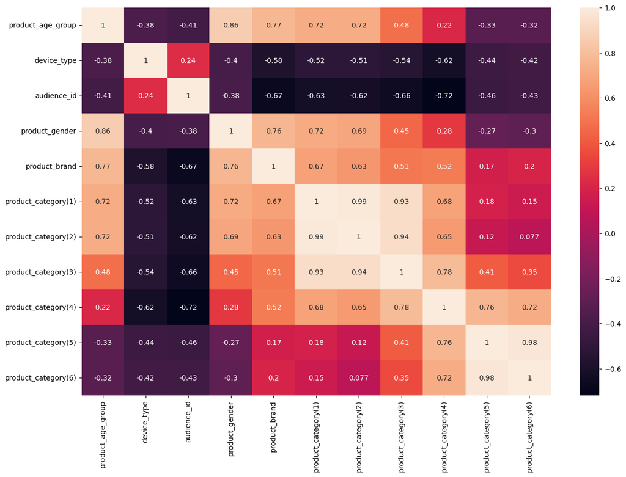

```python
corr = cfit.corr()
plt.subplots(figsize=(15, 10))
sns.heatmap(corr, xticklabels=corr.columns, yticklabels=corr.columns, annot=True)
```

Użyjmy DFS z biblioteki Featuretools, żeby stworzyć dodatkowe cechy datasetu.

```python
df_cleared.head()
```

|  | Sale | SalesAmountInEuro | time_delay_for_conversion | click_timestamp | nb_clicks_1week | product_price | product_age_group | device_type | audience_id | product_gender | product_brand | product_category(1) | product_category(2) | product_category(3) | product_category(4) | product_category(5) | product_category(6) |
| --- | --- | --- | --- | --- | --- | --- | --- | --- | --- | --- | --- | --- | --- | --- | --- | --- | --- |
| 0 | 0 | -1.00000 | -1 | 2020-09-30 03:41:13 | 6 | 0.00 | 4C90FD52FC53D2C1C205844CB69575AB | D7D1FB49049702BF6338894757E0D959 | None | A5D15FC386510762EC0DDFF54ABE6F94 | 635A3EF4F16C9B52F3334F52B864E056 | 033E492229C2222EFAA16EE8A6462D8B | 77FFC91A6157E50A0A114135F18BB1DB | 8A30BF8BD2B3E9D44D2938D42C387D2E | None | None | None |
| 1 | 0 | -1.00000 | -1 | 2020-09-29 13:03:15 | 14 | 0.00 | 4C90FD52FC53D2C1C205844CB69575AB | FF2C446555E3822B0E0FC3406116E86D | 13F966B23C28D8A8FECAFC2FC2CD7E00 | A5D15FC386510762EC0DDFF54ABE6F94 | 777BEECAD173AC93E5CE0CE1CC82DF15 | 033E492229C2222EFAA16EE8A6462D8B | 77FFC91A6157E50A0A114135F18BB1DB | 2E4ED2B95CEF7FD11B282CDFDD56CEA0 | None | None | None |
| 2 | 0 | -1.00000 | -1 | 2020-09-29 08:53:47 | 5 | 0.00 | 4C90FD52FC53D2C1C205844CB69575AB | FF2C446555E3822B0E0FC3406116E86D | None | A5D15FC386510762EC0DDFF54ABE6F94 | 53F02588B177AA9BA649AC9C091F44D4 | 7F286560861764CCB93C90B7AA833949 | 891EE660A73D9A6E1F4BD6149E613C44 | 0279CBF3081FFB710CE52B9E0BA4AABF | 35A13FB2AB63E920B7D71C5957131606 | None | None |
| 3 | 1 | 91.61788 | 619 | 2020-09-29 23:37:43 | 8 | 107.99 | 4C90FD52FC53D2C1C205844CB69575AB | D7D1FB49049702BF6338894757E0D959 | F432D202376506262B3F24AD1D565D4F | A5D15FC386510762EC0DDFF54ABE6F94 | 53F02588B177AA9BA649AC9C091F44D4 | 7F286560861764CCB93C90B7AA833949 | 891EE660A73D9A6E1F4BD6149E613C44 | 0279CBF3081FFB710CE52B9E0BA4AABF | 35A13FB2AB63E920B7D71C5957131606 | None | None |
| 4 | 1 | 23.79454 | 1855650 | 2020-09-29 10:59:49 | 23 | 13.99 | 4C90FD52FC53D2C1C205844CB69575AB | FF2C446555E3822B0E0FC3406116E86D | 32B8ABA7E55F4BB8356338F743EA37AF | A5D15FC386510762EC0DDFF54ABE6F94 | 6271E7ACEF710C0C57E758E473279B63 | 033E492229C2222EFAA16EE8A6462D8B | 77FFC91A6157E50A0A114135F18BB1DB | C08050B58F54FA81F4580ECE15296698 | 067525A83E1875CB1828F4F9ADC752F6 | None | None |

```python
import featuretools as ft
from woodwork.logical_types import Categorical, Boolean, Integer, Double

es = ft.EntitySet(id='sale_data')
es.add_dataframe(dataframe=df_cleared,
                 dataframe_name='sales_info',
                 index='sale_id',
                 make_index=True,
                 time_index='click_timestamp',
                 logical_types={
                     'Sale': Boolean,
                     'SalesAmountInEuro': Double,
                     'time_delay_for_conversion': Integer,
                     'nb_clicks_1week': Integer,
                     'product_price': Double,
                     'product_age_group': Categorical,
                     'device_type': Categorical,
                     'audience_id': Categorical,
                     'product_gender': Categorical,
                     'product_brand': Categorical,
                     'product_category(1)': Categorical,
                     'product_category(2)': Categorical,
                     'product_category(3)': Categorical,
                     'product_category(4)': Categorical,
                     'product_category(5)': Categorical,
                     'product_category(6)': Categorical
                 })
```

```
Entityset: sale_data
  DataFrames:
    sales_info [Rows: 235058, Columns: 18]
  Relationships:
    No relationships
```

Sprawdźmy poprawność entity setu

```python
es['sales_info'].ww.schema
```

| Column | Logical Type | Semantic Tag(s) |
| --- | --- | --- |
| sale_id | Integer | ['index'] |
| Sale | Boolean | [] |
| SalesAmountInEuro | Double | ['numeric'] |
| time_delay_for_conversion | Integer | ['numeric'] |
| click_timestamp | Datetime | ['time_index'] |
| nb_clicks_1week | Integer | ['numeric'] |
| product_price | Double | ['numeric'] |
| product_age_group | Categorical | ['category'] |
| device_type | Categorical | ['category'] |
| audience_id | Categorical | ['category'] |
| product_gender | Categorical | ['category'] |
| product_brand | Categorical | ['category'] |
| product_category(1) | Categorical | ['category'] |
| product_category(2) | Categorical | ['category'] |
| product_category(3) | Categorical | ['category'] |
| product_category(4) | Categorical | ['category'] |
| product_category(5) | Categorical | ['category'] |
| product_category(6) | Categorical | ['category'] |

Tworzę nowe cechy datasetu dla każdej ze zmiennych jakościowych.

```python
es.normalize_dataframe(base_dataframe_name='sales_info',
                       new_dataframe_name='age_groups',
                       index='product_age_group')
es.normalize_dataframe(base_dataframe_name='sales_info',
                       new_dataframe_name='device_types',
                       index='device_type')
es.normalize_dataframe(base_dataframe_name='sales_info',
                       new_dataframe_name='audience_ids',
                       index='audience_id')
es.normalize_dataframe(base_dataframe_name='sales_info',
                       new_dataframe_name='product_genders',
                       index='product_gender')
es.normalize_dataframe(base_dataframe_name='sales_info',
                       new_dataframe_name='product_brands',
                       index='product_brand')
es.normalize_dataframe(base_dataframe_name='sales_info',
                       new_dataframe_name='product_category_1',
                       index='product_category(1)')
es.normalize_dataframe(base_dataframe_name='sales_info',
                       new_dataframe_name='product_category_2',
                       index='product_category(2)')
es.normalize_dataframe(base_dataframe_name='sales_info',
                       new_dataframe_name='product_category_3',
                       index='product_category(3)')
es.normalize_dataframe(base_dataframe_name='sales_info',
                       new_dataframe_name='product_category_4',
                       index='product_category(4)')
es.normalize_dataframe(base_dataframe_name='sales_info',
                       new_dataframe_name='product_category_5',
                       index='product_category(5)')
es.normalize_dataframe(base_dataframe_name='sales_info',
                       new_dataframe_name='product_category_6',
                       index='product_category(6)')
```

```
Entityset: sale_data
  DataFrames:
    sales_info [Rows: 235058, Columns: 18]
    age_groups [Rows: 4, Columns: 2]
    device_types [Rows: 4, Columns: 2]
    audience_ids [Rows: 140, Columns: 2]
    product_genders [Rows: 4, Columns: 2]
    product_brands [Rows: 437, Columns: 2]
    product_category_1 [Rows: 18, Columns: 2]
    product_category_2 [Rows: 75, Columns: 2]
    product_category_3 [Rows: 173, Columns: 2]
    product_category_4 [Rows: 177, Columns: 2]
    product_category_5 [Rows: 63, Columns: 2]
    product_category_6 [Rows: 9, Columns: 2]
  Relationships:
    sales_info.product_age_group -> age_groups.product_age_group
    sales_info.device_type -> device_types.device_type
    sales_info.audience_id -> audience_ids.audience_id
    sales_info.product_gender -> product_genders.product_gender
    sales_info.product_brand -> product_brands.product_brand
    sales_info.product_category(1) -> product_category_1.product_category(1)
    sales_info.product_category(2) -> product_category_2.product_category(2)
    sales_info.product_category(3) -> product_category_3.product_category(3)
    sales_info.product_category(4) -> product_category_4.product_category(4)
    sales_info.product_category(5) -> product_category_5.product_category(5)
    sales_info.product_category(6) -> product_category_6.product_category(6)
```

```python
features = ft.dfs(entityset=es,
                  target_dataframe_name='sales_info',
                  features_only=True,
                  max_depth=2,
                  trans_primitives=['day', 'weekday', 'month'],
                  agg_primitives=['sum', 'mean', 'median'])
features
```

```
[<Feature: Sale>,
 <Feature: SalesAmountInEuro>,
 <Feature: time_delay_for_conversion>,
 <Feature: nb_clicks_1week>,
 <Feature: product_price>,
 <Feature: product_age_group>,
 <Feature: device_type>,
 <Feature: audience_id>,
 <Feature: product_gender>,
 <Feature: product_brand>,
 <Feature: product_category(1)>,
 <Feature: product_category(2)>,
 <Feature: product_category(3)>,
 <Feature: product_category(4)>,
 <Feature: product_category(5)>,
 <Feature: product_category(6)>,
 <Feature: DAY(click_timestamp)>,
 <Feature: MONTH(click_timestamp)>,
 <Feature: WEEKDAY(click_timestamp)>,
 <Feature: age_groups.MEAN(sales_info.SalesAmountInEuro)>,
 <Feature: age_groups.MEAN(sales_info.nb_clicks_1week)>,
 <Feature: age_groups.MEAN(sales_info.product_price)>,
 <Feature: age_groups.MEAN(sales_info.time_delay_for_conversion)>,
 <Feature: age_groups.MEDIAN(sales_info.SalesAmountInEuro)>,
 <Feature: age_groups.MEDIAN(sales_info.nb_clicks_1week)>,
 <Feature: age_groups.MEDIAN(sales_info.product_price)>,
 <Feature: age_groups.MEDIAN(sales_info.time_delay_for_conversion)>,
 <Feature: age_groups.SUM(sales_info.SalesAmountInEuro)>,
 <Feature: age_groups.SUM(sales_info.nb_clicks_1week)>,
 <Feature: age_groups.SUM(sales_info.product_price)>,
 <Feature: age_groups.SUM(sales_info.time_delay_for_conversion)>,
 <Feature: age_groups.DAY(first_sales_info_time)>,
 <Feature: age_groups.MONTH(first_sales_info_time)>,
 <Feature: age_groups.WEEKDAY(first_sales_info_time)>,
 <Feature: device_types.MEAN(sales_info.SalesAmountInEuro)>,
 <Feature: device_types.MEAN(sales_info.nb_clicks_1week)>,
 <Feature: device_types.MEAN(sales_info.product_price)>,
 <Feature: device_types.MEAN(sales_info.time_delay_for_conversion)>,
 <Feature: device_types.MEDIAN(sales_info.SalesAmountInEuro)>,
 <Feature: device_types.MEDIAN(sales_info.nb_clicks_1week)>,
```

[output cut: 129 more lines]

```
 <Feature: product_category_6.MEAN(sales_info.SalesAmountInEuro)>,
 <Feature: product_category_6.MEAN(sales_info.nb_clicks_1week)>,
 <Feature: product_category_6.MEAN(sales_info.product_price)>,
 <Feature: product_category_6.MEAN(sales_info.time_delay_for_conversion)>,
 <Feature: product_category_6.MEDIAN(sales_info.SalesAmountInEuro)>,
 <Feature: product_category_6.MEDIAN(sales_info.nb_clicks_1week)>,
 <Feature: product_category_6.MEDIAN(sales_info.product_price)>,
 <Feature: product_category_6.MEDIAN(sales_info.time_delay_for_conversion)>,
 <Feature: product_category_6.SUM(sales_info.SalesAmountInEuro)>,
 <Feature: product_category_6.SUM(sales_info.nb_clicks_1week)>,
 <Feature: product_category_6.SUM(sales_info.product_price)>,
 <Feature: product_category_6.SUM(sales_info.time_delay_for_conversion)>,
 <Feature: product_category_6.DAY(first_sales_info_time)>,
 <Feature: product_category_6.MONTH(first_sales_info_time)>,
 <Feature: product_category_6.WEEKDAY(first_sales_info_time)>]
```

```python
feature_matrix = ft.calculate_feature_matrix(features=features, entityset=es)
feature_matrix
```

| sale_id | Sale | SalesAmountInEuro | time_delay_for_conversion | nb_clicks_1week | product_price | product_age_group | device_type | audience_id | product_gender | product_brand | ... | product_category_6.MEDIAN(sales_info.nb_clicks_1week) | product_category_6.MEDIAN(sales_info.product_price) | product_category_6.MEDIAN(sales_info.time_delay_for_conversion) | product_category_6.SUM(sales_info.SalesAmountInEuro) | product_category_6.SUM(sales_info.nb_clicks_1week) | product_category_6.SUM(sales_info.product_price) | product_category_6.SUM(sales_info.time_delay_for_conversion) | product_category_6.DAY(first_sales_info_time) | product_category_6.MONTH(first_sales_info_time) | product_category_6.WEEKDAY(first_sales_info_time) |
| --- | --- | --- | --- | --- | --- | --- | --- | --- | --- | --- | --- | --- | --- | --- | --- | --- | --- | --- | --- | --- | --- |
| 210032 | False | -1.00000 | -1 | 3 | 0.00 | 4C90FD52FC53D2C1C205844CB69575AB | 7E56C27BFF0305E788DA55A029EC4988 | None | A5D15FC386510762EC0DDFF54ABE6F94 | 53F02588B177AA9BA649AC9C091F44D4 | ... | 10.0 | 0.0 | -1.0 | 7.430649e+06 | 12838415.0 | 3319403.08 | 2.262119e+10 | 3 | 8 | 0 |
| 225166 | False | -1.00000 | -1 | 20 | 0.00 | 4C90FD52FC53D2C1C205844CB69575AB | D7D1FB49049702BF6338894757E0D959 | None | A5D15FC386510762EC0DDFF54ABE6F94 | 39A582C8A8DDBEB38514DC3C5631ED65 | ... | 10.0 | 0.0 | -1.0 | 7.430649e+06 | 12838415.0 | 3319403.08 | 2.262119e+10 | 3 | 8 | 0 |
| 225190 | False | -1.00000 | -1 | 64 | 0.00 | 4C90FD52FC53D2C1C205844CB69575AB | FF2C446555E3822B0E0FC3406116E86D | None | A5D15FC386510762EC0DDFF54ABE6F94 | 5730A6E20EFA239FC9968766E94FC1FB | ... | 10.0 | 0.0 | -1.0 | 7.430649e+06 | 12838415.0 | 3319403.08 | 2.262119e+10 | 3 | 8 | 0 |
| 233830 | True | 166.22050 | 726 | 0 | 74.97 | 4C90FD52FC53D2C1C205844CB69575AB | 7E56C27BFF0305E788DA55A029EC4988 | None | A5D15FC386510762EC0DDFF54ABE6F94 | 5988945F3727F7C82157CEBF67D822D4 | ... | 10.0 | 0.0 | -1.0 | 7.430649e+06 | 12838415.0 | 3319403.08 | 2.262119e+10 | 3 | 8 | 0 |
| 116183 | False | -1.00000 | -1 | 12 | 0.00 | 4C90FD52FC53D2C1C205844CB69575AB | 7E56C27BFF0305E788DA55A029EC4988 | 17F20B29B2A3D5ACEB7F5CF6385DBD02 | A5D15FC386510762EC0DDFF54ABE6F94 | 53F02588B177AA9BA649AC9C091F44D4 | ... | 10.0 | 0.0 | -1.0 | 7.430649e+06 | 12838415.0 | 3319403.08 | 2.262119e+10 | 3 | 8 | 0 |
| ... | ... | ... | ... | ... | ... | ... | ... | ... | ... | ... | ... | ... | ... | ... | ... | ... | ... | ... | ... | ... | ... |
| 152922 | False | -1.00000 | -1 | 16 | 0.00 | 4C90FD52FC53D2C1C205844CB69575AB | D7D1FB49049702BF6338894757E0D959 | None | C45A9AC6D102ACAEEDF0D6F78636D84A | 3491B0F7C3C0D6684C5E0CF18D6BE834 | ... | 10.0 | 0.0 | -1.0 | 7.430649e+06 | 12838415.0 | 3319403.08 | 2.262119e+10 | 3 | 8 | 0 |
| 15763 | False | -1.00000 | -1 | 50 | 0.00 | 4C90FD52FC53D2C1C205844CB69575AB | 7E56C27BFF0305E788DA55A029EC4988 | None | C45A9AC6D102ACAEEDF0D6F78636D84A | 6C0F874E8CD1A6F748737B6B5CB057F5 | ... | 10.0 | 0.0 | -1.0 | 7.430649e+06 | 12838415.0 | 3319403.08 | 2.262119e+10 | 3 | 8 | 0 |
| 152902 | False | -1.00000 | -1 | 30 | 0.00 | 4C90FD52FC53D2C1C205844CB69575AB | D7D1FB49049702BF6338894757E0D959 | None | A5D15FC386510762EC0DDFF54ABE6F94 | A51459F2008EB80D460C2463096349D8 | ... | 10.0 | 0.0 | -1.0 | 7.430649e+06 | 12838415.0 | 3319403.08 | 2.262119e+10 | 3 | 8 | 0 |
| 4588 | True | 74.91388 | 222743 | 29 | 86.99 | 4C90FD52FC53D2C1C205844CB69575AB | D7D1FB49049702BF6338894757E0D959 | None | A5D15FC386510762EC0DDFF54ABE6F94 | E15F861F6390FAC60799ACA9F596BC58 | ... | 10.0 | 0.0 | -1.0 | 7.430649e+06 | 12838415.0 | 3319403.08 | 2.262119e+10 | 3 | 8 | 0 |
| 91867 | False | -1.00000 | -1 | 79 | 0.00 | 4C90FD52FC53D2C1C205844CB69575AB | 7E56C27BFF0305E788DA55A029EC4988 | None | C45A9AC6D102ACAEEDF0D6F78636D84A | C153E8F0FBDDA2D14CC066665B07AE35 | ... | 10.0 | 0.0 | -1.0 | 7.430649e+06 | 12838415.0 | 3319403.08 | 2.262119e+10 | 3 | 8 | 0 |

235058 rows × 184 columns

# PCA

Po stworzeniu nowych cech datasetu, czas na przesianie szumu - nieistotnych zmiennych. Użyję do tego dekompozycji widmowej w implementacji biblioteki sklearn

Jednak przed użyciem PCA, warto usunąć silnie skorelowane kolumny.

```python
df_pca = feature_matrix
# df_pca
corr=df_pca.corr()
corr
```

|  | Sale | SalesAmountInEuro | time_delay_for_conversion | nb_clicks_1week | product_price | age_groups.MEAN(sales_info.SalesAmountInEuro) | age_groups.MEAN(sales_info.nb_clicks_1week) | age_groups.MEAN(sales_info.product_price) | age_groups.MEAN(sales_info.time_delay_for_conversion) | age_groups.MEDIAN(sales_info.SalesAmountInEuro) | ... | product_category_6.MEAN(sales_info.product_price) | product_category_6.MEAN(sales_info.time_delay_for_conversion) | product_category_6.MEDIAN(sales_info.SalesAmountInEuro) | product_category_6.MEDIAN(sales_info.nb_clicks_1week) | product_category_6.MEDIAN(sales_info.product_price) | product_category_6.MEDIAN(sales_info.time_delay_for_conversion) | product_category_6.SUM(sales_info.SalesAmountInEuro) | product_category_6.SUM(sales_info.nb_clicks_1week) | product_category_6.SUM(sales_info.product_price) | product_category_6.SUM(sales_info.time_delay_for_conversion) |
| --- | --- | --- | --- | --- | --- | --- | --- | --- | --- | --- | --- | --- | --- | --- | --- | --- | --- | --- | --- | --- | --- |
| Sale | 1.000000 | 0.467050 | 0.529441 | -0.041992 | 0.547920 | 0.016098 | 0.016581 | 0.014393 | 0.008216 | NaN | ... | 0.005514 | 0.005055 | 0.004143 | 0.002791 | 0.004143 | 0.004143 | -0.002231 | -0.002231 | -0.002231 | -0.002230 |
| SalesAmountInEuro | 0.467050 | 1.000000 | 0.323105 | -0.021192 | 0.506952 | 0.009636 | 0.009424 | 0.008904 | 0.003468 | NaN | ... | 0.002182 | 0.000085 | 0.001193 | -0.000159 | 0.001193 | 0.001193 | 0.000977 | 0.000977 | 0.000977 | 0.000978 |
| time_delay_for_conversion | 0.529441 | 0.323105 | 1.000000 | -0.024591 | 0.282419 | 0.004012 | 0.003467 | -0.000126 | 0.011149 | NaN | ... | 0.002845 | 0.011723 | 0.001366 | 0.007226 | 0.001366 | 0.001366 | -0.009199 | -0.009199 | -0.009199 | -0.009198 |
| nb_clicks_1week | -0.041992 | -0.021192 | -0.024591 | 1.000000 | -0.016795 | 0.036187 | 0.037003 | 0.034806 | 0.011508 | NaN | ... | 0.002205 | -0.001783 | -0.000681 | 0.002064 | -0.000681 | -0.000681 | 0.002359 | 0.002360 | 0.002359 | 0.002361 |
| product_price | 0.547920 | 0.506952 | 0.282419 | -0.016795 | 1.000000 | 0.011866 | 0.012079 | 0.012841 | -0.000145 | NaN | ... | 0.002607 | 0.000633 | 0.001506 | 0.000050 | 0.001506 | 0.001506 | 0.000610 | 0.000610 | 0.000610 | 0.000610 |
| ... | ... | ... | ... | ... | ... | ... | ... | ... | ... | ... | ... | ... | ... | ... | ... | ... | ... | ... | ... | ... | ... |
| product_category_6.MEDIAN(sales_info.time_delay_for_conversion) | 0.004143 | 0.001193 | 0.001366 | -0.000681 | 0.001506 | 0.000246 | 0.000250 | 0.000282 | -0.000046 | NaN | ... | 0.577673 | 0.116530 | 1.000000 | -0.010976 | 1.000000 | 1.000000 | -0.056423 | -0.056431 | -0.056425 | -0.056457 |
| product_category_6.SUM(sales_info.SalesAmountInEuro) | -0.002231 | 0.000977 | -0.009199 | 0.002359 | 0.000610 | -0.004359 | -0.004440 | -0.005002 | 0.000815 | NaN | ... | 0.233828 | -0.784671 | -0.056423 | -0.759653 | -0.056423 | -0.056423 | 1.000000 | 1.000000 | 1.000000 | 1.000000 |
| product_category_6.SUM(sales_info.nb_clicks_1week) | -0.002231 | 0.000977 | -0.009199 | 0.002360 | 0.000610 | -0.004359 | -0.004440 | -0.005002 | 0.000815 | NaN | ... | 0.233853 | -0.784673 | -0.056431 | -0.759584 | -0.056431 | -0.056431 | 1.000000 | 1.000000 | 1.000000 | 1.000000 |
| product_category_6.SUM(sales_info.product_price) | -0.002231 | 0.000977 | -0.009199 | 0.002359 | 0.000610 | -0.004359 | -0.004440 | -0.005002 | 0.000815 | NaN | ... | 0.233836 | -0.784668 | -0.056425 | -0.759640 | -0.056425 | -0.056425 | 1.000000 | 1.000000 | 1.000000 | 1.000000 |
| product_category_6.SUM(sales_info.time_delay_for_conversion) | -0.002230 | 0.000978 | -0.009198 | 0.002361 | 0.000610 | -0.004359 | -0.004440 | -0.005002 | 0.000815 | NaN | ... | 0.233941 | -0.784635 | -0.056457 | -0.759457 | -0.056457 | -0.056457 | 1.000000 | 1.000000 | 1.000000 | 1.000000 |

137 rows × 137 columns

```python
threshold = 0.8
triangle = corr.where(np.triu(np.ones(corr.shape), k=1).astype(bool))
collinears = [c for c in triangle.columns if any(abs(triangle[c]) > threshold)]
collinears
df_pca = df_pca.drop(df_pca[collinears], axis=1)
```

Jako, że przygotowujemy się do zredukowania wymiarowości datasetu za pomocą PCA, musimy usunąć z niego wszystkie zmienne jakościowe - wyciągnęliśmy już z nich potrzebne zależności.

```python
df_pca = df_pca.drop(['product_age_group', 'device_type', 'audience_id',
             'product_gender', 'product_brand', 'product_category(1)',
             'product_category(2)', 'product_category(3)', 'product_category(4)',
             'product_category(5)', 'product_category(6)'], axis=1)
df_pca.select_dtypes(include='category')
```

| sale_id | DAY(click_timestamp) | MONTH(click_timestamp) | WEEKDAY(click_timestamp) | age_groups.DAY(first_sales_info_time) | age_groups.MONTH(first_sales_info_time) | age_groups.WEEKDAY(first_sales_info_time) | device_types.DAY(first_sales_info_time) | device_types.MONTH(first_sales_info_time) | device_types.WEEKDAY(first_sales_info_time) | audience_ids.DAY(first_sales_info_time) | ... | product_category_3.WEEKDAY(first_sales_info_time) | product_category_4.DAY(first_sales_info_time) | product_category_4.MONTH(first_sales_info_time) | product_category_4.WEEKDAY(first_sales_info_time) | product_category_5.DAY(first_sales_info_time) | product_category_5.MONTH(first_sales_info_time) | product_category_5.WEEKDAY(first_sales_info_time) | product_category_6.DAY(first_sales_info_time) | product_category_6.MONTH(first_sales_info_time) | product_category_6.WEEKDAY(first_sales_info_time) |
| --- | --- | --- | --- | --- | --- | --- | --- | --- | --- | --- | --- | --- | --- | --- | --- | --- | --- | --- | --- | --- | --- |
| 210032 | 3 | 8 | 0 | 3 | 8 | 0 | 3 | 8 | 0 | 3 | ... | 0 | 3 | 8 | 0 | 3 | 8 | 0 | 3 | 8 | 0 |
| 225166 | 3 | 8 | 0 | 3 | 8 | 0 | 3 | 8 | 0 | 3 | ... | 0 | 3 | 8 | 0 | 3 | 8 | 0 | 3 | 8 | 0 |
| 225190 | 3 | 8 | 0 | 3 | 8 | 0 | 3 | 8 | 0 | 3 | ... | 0 | 3 | 8 | 0 | 3 | 8 | 0 | 3 | 8 | 0 |
| 233830 | 3 | 8 | 0 | 3 | 8 | 0 | 3 | 8 | 0 | 3 | ... | 0 | 3 | 8 | 0 | 3 | 8 | 0 | 3 | 8 | 0 |
| 116183 | 3 | 8 | 0 | 3 | 8 | 0 | 3 | 8 | 0 | 3 | ... | 0 | 3 | 8 | 0 | 3 | 8 | 0 | 3 | 8 | 0 |
| ... | ... | ... | ... | ... | ... | ... | ... | ... | ... | ... | ... | ... | ... | ... | ... | ... | ... | ... | ... | ... | ... |
| 152922 | 2 | 11 | 0 | 3 | 8 | 0 | 3 | 8 | 0 | 3 | ... | 3 | 3 | 8 | 0 | 3 | 8 | 0 | 3 | 8 | 0 |
| 15763 | 2 | 11 | 0 | 3 | 8 | 0 | 3 | 8 | 0 | 3 | ... | 0 | 3 | 8 | 0 | 3 | 8 | 0 | 3 | 8 | 0 |
| 152902 | 2 | 11 | 0 | 3 | 8 | 0 | 3 | 8 | 0 | 3 | ... | 0 | 3 | 8 | 0 | 3 | 8 | 0 | 3 | 8 | 0 |
| 4588 | 2 | 11 | 0 | 3 | 8 | 0 | 3 | 8 | 0 | 3 | ... | 0 | 3 | 8 | 0 | 3 | 8 | 0 | 3 | 8 | 0 |
| 91867 | 2 | 11 | 0 | 3 | 8 | 0 | 3 | 8 | 0 | 3 | ... | 1 | 3 | 8 | 0 | 3 | 8 | 0 | 3 | 8 | 0 |

235058 rows × 36 columns

Podzielmy nasze dane na cel - Y oraz cechy - X.

```python
X = df_pca.drop('Sale', axis=1)
Y = df_pca['Sale']
X.isnull().any()
```

```
SalesAmountInEuro                                        False
time_delay_for_conversion                                False
nb_clicks_1week                                          False
product_price                                            False
DAY(click_timestamp)                                     False
                                                         ...
product_category_6.MEDIAN(sales_info.nb_clicks_1week)    False
product_category_6.SUM(sales_info.SalesAmountInEuro)     False
product_category_6.DAY(first_sales_info_time)            False
product_category_6.MONTH(first_sales_info_time)          False
product_category_6.WEEKDAY(first_sales_info_time)        False
Length: 103, dtype: bool
```

Jako, że PCA działa najlepiej na danych znormalizowanych, przeprowadźmy ją za pomocą StandardScalera w implementacji sklearn.

```python
from sklearn.decomposition import PCA
from sklearn.preprocessing import StandardScaler

pca = PCA()
scaler = StandardScaler()
X_b = scaler.fit_transform(X)
# print(X)

pca.fit_transform(X_b)
```

```
array([[ 3.08821446e+00, -1.27969041e+00, -6.34747679e-01, ...,
         2.51519955e-15, -3.65790199e-15,  5.59410499e-16],
       [ 2.57045287e+00, -1.32701606e+00, -5.08409480e-01, ...,
        -7.52771731e-16, -1.11746981e-15,  1.50132359e-16],
       [ 2.61007266e+00, -1.15395733e+00, -6.52620628e-01, ...,
        -1.77480691e-15, -2.23654978e-15,  2.05496772e-16],
       ...,
       [ 3.00746687e+00, -1.58321295e+00,  7.42633269e-02, ...,
        -6.06889773e-19,  7.01772386e-17, -9.21985081e-18],
       [ 3.68446420e+00, -1.60656597e+00,  7.87397693e-02, ...,
         1.59341294e-17,  4.91600985e-17, -6.24590090e-18],
       [-4.17667451e+00, -6.62589789e-01,  1.64115299e+00, ...,
        -2.04811744e-17,  4.54428584e-17, -6.50463802e-18]])
```

Po pomyślnym wykonaniu dekompozycji, sprawdźmy ile głównych cech powinniśmy wybrać dla dalszej analizy.

```python
feats = range(pca.n_components_)
var_sum = np.cumsum(pca.explained_variance_ratio_)
print(var_sum)
```

```
[0.092611   0.15432724 0.20396546 0.25204807 0.29739982 0.33643163
 0.37305909 0.407661   0.4393182  0.46737318 0.49208123 0.51495875
 0.537151   0.55790543 0.57821421 0.59783998 0.61650787 0.63369024
 0.65046001 0.66673523 0.68239123 0.69783424 0.71222683 0.72652871
 0.73917702 0.75154623 0.76355703 0.77487445 0.78605074 0.79710274
 0.80784925 0.81798102 0.82761047 0.83699925 0.84605146 0.85425267
 0.8622853  0.86988729 0.87738697 0.88460088 0.89163352 0.89805875
 0.90397048 0.90970377 0.91541    0.92094891 0.92640137 0.9315514
 0.93606992 0.94056794 0.94456082 0.9484701  0.95229567 0.95594956
 0.9594928  0.96286174 0.96620322 0.96911479 0.97193343 0.97454896
 0.97704047 0.97933928 0.98146923 0.98344438 0.98534458 0.9871104
 0.98877241 0.99030742 0.99176111 0.99308684 0.99406945 0.99498077
 0.99575828 0.99648762 0.99714868 0.99775449 0.998235   0.99867364
 0.99909797 0.99949655 0.99970247 0.999856   0.9999481  0.99997588
 1.         1.         1.         1.         1.         1.
 1.         1.         1.         1.         1.         1.
 1.         1.         1.         1.         1.         1.
 1.        ]
```

Teraz zobaczmy to na wykresie

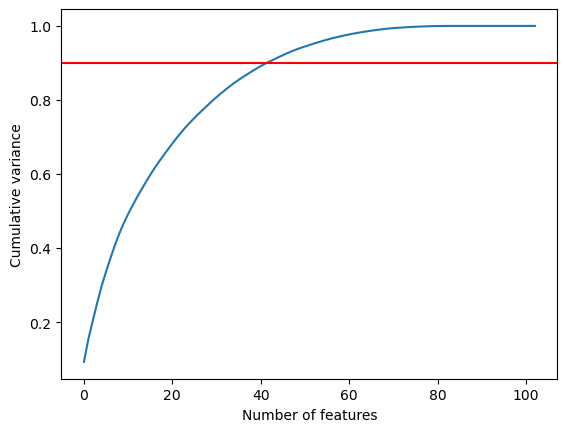

```python
plt.plot(var_sum)
plt.axhline(y=0.9, color='r')
plt.xlabel('Number of features')
plt.ylabel('Cumulative variance')
plt.show()
```

Na powyższym wykresie możemy zauważyć, że pierwsze ok. 40 cech zawiera 90% informacji o datasecie. Wybieram zatem tę liczbę jako liczbę komponentów do dalszej analizy.

```python
from sklearn.model_selection import train_test_split
X_train, X_test, Y_train, Y_test = train_test_split(X, Y, test_size=0.3, random_state=420)
scaler = StandardScaler()
scaler.fit(X_train)

scaler.transform(X_train)
scaler.transform(X_test) # na danych testowych przeprowadzamy tylko transformację,
                         # żeby nasz model nie znał parametrów danych testowych
pca_f = PCA(n_components=40)
pca_f.fit(X_train)
```

```
PCA(n_components=40)
```

```python
print(pca_f.explained_variance_,
      "\n-------------------------------------------------------------------\n",
      pca_f.explained_variance_ratio_)
```

```
[2.41165678e+12 2.00495069e+12 1.46137545e+12 1.06632398e+12
 9.97506795e+11 4.76066227e+11 3.24865992e+11 1.28268943e+11
 7.22344254e+10 3.12398316e+10 9.17817677e+08 4.13724095e+08
 2.24133831e+08 1.17865919e+08 6.02235777e+07 1.84898503e+07
 1.51980196e+07 7.11557808e+06 3.28510555e+06 6.17227549e+04
 2.07918335e+04 1.76775403e+04 2.39575726e+03 2.00328824e+03
 1.24896349e+03 9.02266513e+02 5.09386630e+02 1.50128649e+02
 1.30263611e+02 9.63355015e+01 8.79980258e+01 8.34389785e+01
 6.83122617e+01 5.62869160e+01 4.38758503e+01 3.52916412e+01
 3.00198506e+01 1.78176581e+01 1.68142604e+01 1.45805773e+01]
-------------------------------------------------------------------
 [2.68670345e-01 2.23361301e-01 1.62804364e-01 1.18793701e-01
 1.11127130e-01 5.30361032e-02 3.61916584e-02 1.42897868e-02
 8.04726784e-03 3.48026984e-03 1.02249373e-04 4.60908851e-05
 2.49696036e-05 1.31308391e-05 6.70920073e-06 2.05985964e-06
 1.69313362e-06 7.92710157e-07 3.65976805e-07 6.87621640e-09
 2.31631182e-09 1.96936434e-09 2.66899062e-10 2.23176095e-10
 1.39140634e-10 1.00516897e-10 5.67481588e-11 1.67250648e-11
 1.45120026e-11 1.07322454e-11 9.80340993e-12 9.29550979e-12
 7.61031965e-12 6.27063739e-12 4.88798404e-12 3.93166122e-12
 3.34435800e-12 1.98497415e-12 1.87319074e-12 1.62434754e-12]
```

```python
X_train = pca_f.transform(X_train)
X_test = pca_f.transform(X_test)
```

Naszym problemem jest przyporządkowanie czy dany produkt został sprzedany - czy nie. Jest to zatem problem klasyfikacji. Najpierw, żeby mieć odnośnik do porównania wyników, użyję prostej regresji logistycznej w implementacji sklearn. Potem porównam wyniki z biblioteką TPOT.

```python
from sklearn.linear_model import LogisticRegression
lr = LogisticRegression(random_state=420)
lr.fit(X_train, Y_train)
Y_pred = lr.predict(X_test)
```

Sprawdźmy wynik predykcji.

```python
from sklearn.metrics import mean_squared_error
mse = mean_squared_error
score_lr = lr.score(X_test, Y_test)
print("Model accuracy: {}".format(round(score_lr, 3)))
y_test = [int(x) for x in Y_test]
y_pred = [int(x) for x in Y_pred]
rmse = np.sqrt(mse(y_test, y_pred))
print("Prediction RMSE: {}".format(round(rmse, 3)))
```

```
Model accuracy: 0.898
Prediction RMSE: 0.32
```

Pomimo, że model nie był w żaden sposób tuningowany, udało sie osiągnąć celność prawie 90% i niską wartość średniej kwadratowej błędów (RMSE).

# TPOT

```python
from tpot import TPOTClassifier
```

```python
tpot = TPOTClassifier(verbosity=2, max_time_mins=10)
tpot.fit(X_train, Y_train)
```

```
10.55 minutes have elapsed. TPOT will close down.
TPOT closed during evaluation in one generation.
WARNING: TPOT may not provide a good pipeline if TPOT is stopped/interrupted in a early generation.


TPOT closed prematurely. Will use the current best pipeline.

Best pipeline: ExtraTreesClassifier(input_matrix, bootstrap=False, criterion=entropy, max_features=0.6500000000000001, min_samples_leaf=3, min_samples_split=15, n_estimators=100)
```

```
TPOTClassifier(max_time_mins=10, verbosity=2)
```

TPOT szuka najlepszego modelu poprzez sprawdzian krzyżowy (Cross Validation) i na końcu zwraca najcelniejszy model (cały pipeline modelu wraz ze wszystkimi przetestowanymi hiperzmiennymi).

Po 10 minutach TPOT za najskuteczniejszy model uznał 3 razy uznał DecisionTreeClassifier z celnościami: 99.7%, 95.5%, 90.3%. Najskuteczniejsza okazała się ostatnia próba z wybranym modelem ExtraTreesClassifier. Cały pipeline dla najskuteczniejszego podejścia: **ExtraTreesClassifier(input_matrix, bootstrap=False, criterion=entropy, max_features=0.6500000000000001, min_samples_leaf=3, min_samples_split=15, n_estimators=100)**

```python
tpot_10min = tpot.fitted_pipeline_
tpot_10min
```

```
Pipeline(steps=[('extratreesclassifier',
                 ExtraTreesClassifier(criterion='entropy',
                                      max_features=0.6500000000000001,
                                      min_samples_leaf=3,
                                      min_samples_split=15))])
```

```python
tpot_10min_score = tpot_10min.score(X_test, Y_test)
print("TPOT accuracy after 10 minutes: {}".format(round(tpot_10min_score, 3)))
```

```
TPOT accuracy after 10 minutes: 0.999
```

Dla kilku wykonanych prób: Bibliotece TPOT już po 10 minutach udało się uzyskać celność: 99.9%, 99.7%, 95.5%, 90.3%.

# Analiza zmienych opisujących i zmiennej opisywanej

```python
df.head()
```

|  | Sale | SalesAmountInEuro | time_delay_for_conversion | click_timestamp | nb_clicks_1week | product_price | product_age_group | device_type | audience_id | product_gender | ... | product_category(3) | product_category(4) | product_category(5) | product_category(6) | product_category(7) | product_country | product_id | product_title | partner_id | user_id |
| --- | --- | --- | --- | --- | --- | --- | --- | --- | --- | --- | --- | --- | --- | --- | --- | --- | --- | --- | --- | --- | --- |
| 0 | 0 | -1.00000 | -1 | 1601437273 | 6 | 0.00 | 4C90FD52FC53D2C1C205844CB69575AB | D7D1FB49049702BF6338894757E0D959 | None | A5D15FC386510762EC0DDFF54ABE6F94 | ... | 8A30BF8BD2B3E9D44D2938D42C387D2E | None | None | None | -1 | 2AC62132FBCFA093B9426894A4BC6278 | 77AEF49D383E58FA384E99C177BF62D6 | F0F9816E146A3DF9B8A99B3B12A77362 922FACDC63DBA... | 9FF550C0B17A3C493378CB6E2DEEE6E4 | BB3F8CAD8C5AAF88CD7BE8C6FC356A2D |
| 1 | 0 | -1.00000 | -1 | 1601384595 | 14 | 0.00 | 4C90FD52FC53D2C1C205844CB69575AB | FF2C446555E3822B0E0FC3406116E86D | 13F966B23C28D8A8FECAFC2FC2CD7E00 | A5D15FC386510762EC0DDFF54ABE6F94 | ... | 2E4ED2B95CEF7FD11B282CDFDD56CEA0 | None | None | None | -1 | 2AC62132FBCFA093B9426894A4BC6278 | 3D55D8AEBBDAA58EB5FAA244601242D3 | 777BEECAD173AC93E5CE0CE1CC82DF15 65C0CABE6A2B2... | 9FF550C0B17A3C493378CB6E2DEEE6E4 | 8275B52D8FD8CBDA13BC2B36F110856C |
| 2 | 0 | -1.00000 | -1 | 1601369627 | 5 | 0.00 | 4C90FD52FC53D2C1C205844CB69575AB | FF2C446555E3822B0E0FC3406116E86D | None | A5D15FC386510762EC0DDFF54ABE6F94 | ... | 0279CBF3081FFB710CE52B9E0BA4AABF | 35A13FB2AB63E920B7D71C5957131606 | None | None | -1 | 2AC62132FBCFA093B9426894A4BC6278 | FADA68550BC65EF5F94718C02E437AA8 | C1B4729F10A2EA1402FBFB449E38825F 078EE401D7044... | 9FF550C0B17A3C493378CB6E2DEEE6E4 | 63D63E591416C1DD1EA80474EFD36E99 |
| 3 | 1 | 91.61788 | 619 | 1601422663 | 8 | 107.99 | 4C90FD52FC53D2C1C205844CB69575AB | D7D1FB49049702BF6338894757E0D959 | F432D202376506262B3F24AD1D565D4F | A5D15FC386510762EC0DDFF54ABE6F94 | ... | 0279CBF3081FFB710CE52B9E0BA4AABF | 35A13FB2AB63E920B7D71C5957131606 | None | None | -1 | 2AC62132FBCFA093B9426894A4BC6278 | 4EB3BA0A95DCD9C6B9906C160C7FE4BD | C1B4729F10A2EA1402FBFB449E38825F 078EE401D7044... | 9FF550C0B17A3C493378CB6E2DEEE6E4 | 1CFBA4098ABC71751ECEEDFE2D59BE4D |
| 4 | 1 | 23.79454 | 1855650 | 1601377189 | 23 | 13.99 | 4C90FD52FC53D2C1C205844CB69575AB | FF2C446555E3822B0E0FC3406116E86D | 32B8ABA7E55F4BB8356338F743EA37AF | A5D15FC386510762EC0DDFF54ABE6F94 | ... | C08050B58F54FA81F4580ECE15296698 | 067525A83E1875CB1828F4F9ADC752F6 | None | None | -1 | 2AC62132FBCFA093B9426894A4BC6278 | 5EAD3217B11B8F3DFF3403453E9A53AD | 4BCB07CC282329F41EF71E62693EBDAA 08DE6267A8660... | 9FF550C0B17A3C493378CB6E2DEEE6E4 | 692FB9599DAB1062AC09F218323CAB25 |

5 rows × 23 columns

```python
df_op = df
df_op['click_timestamp'] = pd.to_datetime(df_op['click_timestamp'], unit='s')
df_op = df_op[df_op['Sale'] == 1]
df_op = df_op[df_op['nb_clicks_1week'] >= 0]
df_op['click_timestamp'] = pd.DatetimeIndex(df_op['click_timestamp']).normalize()
df_ts = df_op.groupby(['click_timestamp', 'product_id'], as_index=False)['nb_clicks_1week', 'SalesAmountInEuro', 'product_price', 'product_brand'].sum()
df_ts
```

|  | click_timestamp | product_id | nb_clicks_1week | SalesAmountInEuro | product_price |
| --- | --- | --- | --- | --- | --- |
| 0 | 2020-08-03 | 05DDF1D10635207F22A225376369D62F | 1 | 175.33728 | 47.99 |
| 1 | 2020-08-03 | 0AC4489C14365574582F063B25703649 | 53 | 25.57346 | 29.99 |
| 2 | 2020-08-03 | 118192906B12CD43DB9576D001A253FE | 0 | 98.80621 | 11.99 |
| 3 | 2020-08-03 | 14E5BF4177DB3FC411A9FF1B19FF67D2 | 4 | 51.15545 | 59.99 |
| 4 | 2020-08-03 | 25D62AC9DEA71D7AB6064DE17D232BDC | 29 | 92.70232 | 47.00 |
| ... | ... | ... | ... | ... | ... |
| 42305 | 2020-11-02 | FA7DA1AAD8D29718B744C35CC6551869 | 12 | 75.94140 | 88.13 |
| 42306 | 2020-11-02 | FC71FF0889500360112CC3D8214D657E | 0 | 1150.36620 | 695.00 |
| 42307 | 2020-11-02 | FDB498D7DF8048BDD8DD1D0C0C232218 | 16 | 60.28246 | 20.00 |
| 42308 | 2020-11-02 | FF712FDC2DE4950D9342EB429A886C37 | 0 | 418.38241 | 55.00 |
| 42309 | 2020-11-02 | FFAA7AB5D2247B75BA102491C6F3F011 | 8 | 310.15938 | 59.99 |

42310 rows × 5 columns

```python
df_ts.describe()
```

|  | nb_clicks_1week | SalesAmountInEuro | product_price |
| --- | --- | --- | --- |
| count | 42310.000000 | 42310.000000 | 42310.000000 |
| mean | 46.899905 | 179.603238 | 78.227052 |
| std | 282.676100 | 299.699198 | 107.699264 |
| min | 0.000000 | 0.016960 | 0.010000 |
| 25% | 1.000000 | 56.417120 | 28.990000 |
| 50% | 6.000000 | 106.245810 | 49.980000 |
| 75% | 24.000000 | 200.642480 | 99.500000 |
| max | 13826.000000 | 15296.655370 | 12300.000000 |

Przyjrzyjmy się parze: SalesAmountInEuro i nb_clicks_1_week na wykresie na osi click_timestamp.

```
(array([18475., 18489., 18506., 18520., 18536., 18550., 18567.]),
 [Text(18475.0, 0, '2020-08-01'),
```

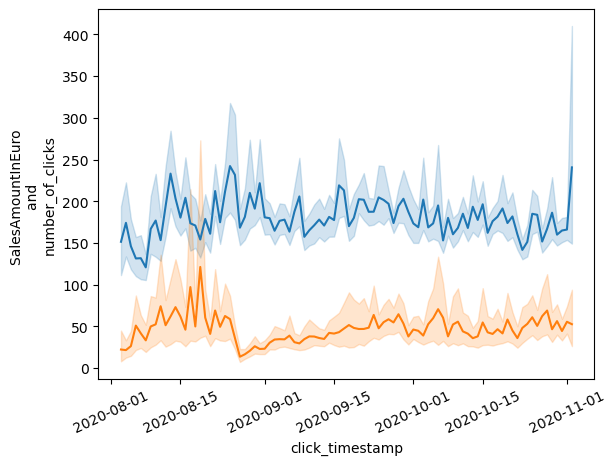

```python
sns.lineplot(x='click_timestamp', y='SalesAmountInEuro', data=df_ts)
sns.lineplot(x='click_timestamp', y='nb_clicks_1week', data=df_ts)
plt.ylabel('SalesAmountInEuro \nand \nnumber_of_clicks')
plt.xticks(rotation=25)
```

Poza sporadycznymi skorelowanymi wyskokami od "normy", raczej ilość kliknięć nie ma znacznego wpływu na wartość sprzedaży danego dnia. W przypadku z dni 15-20-08-2020 ilość kliknięć jest wręcz odwrotnie proporcjonalna do wartości sprzedanych produktów. Mogło to być spowodowane np. wyjściem oczekiwanego, popularnego produktu do sprzedaży, który niekoniecznie dobrze się sprzedawał. Pod koniec, SalesAmountInEuro wyraźnie skoczył w górę, co zostało spowodowane outlierem - pojedynczą sprzedażą produktu znacznie odbiegającego cenowo od średniej populacji.

Sprawdźmy jeszcze jak ma się korelacja zmiennych opisujących do zmiennej opisywanej SalesAmountInEuro.

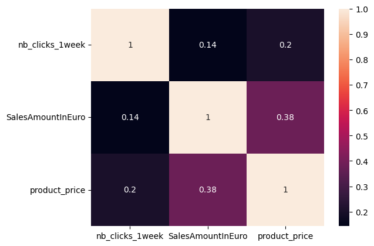

```python
corr = df_ts.corr()
sns.heatmap(data=corr, xticklabels=corr.columns, yticklabels=corr.columns, annot=True)
```

Jak można zauważyć, istnieje słaba pozytywna korelacja między ilością kliknięć i wartością sprzedanych produktów oraz przeciętna pozytywna korelacja między ceną produktu a sumaryczną wartością sprzedaży - droższe produkty podbijają również sumę sprzedaży.

### Wnioski

- Część dotycząca testu statystycznego:
- - wybrałem test Z dla jednej proporcji, ponieważ chciałem zbadać zależność pomiędzy najlepiej sprzedającymi się produktami a resztą populacji. Wniosek: proporcja sprzedaży do wyświetleń bardzo zbliżona do średniej populacji - nie odbiega znacząco.
- Cześć dotycząca inżynierii cech:
- - DFS upraszcza i znacznie przyspiesza proces tworzenia dodatkowych cech ze zmiennych jakościowych. Nawet z pozornie bardzo silnie skorelowanych, algorytm wyciągnął głębsze zależności mające wpływ na model.
- - TPOT pozwala na automatyczne dobranie optymalnego modelu dla danej funkcji celu i cech. Jego dużym minusem jest jednak czasochłonność - porównuje wszystkie modele z różnymi hiperparametrami ze sobą, wymaga dużej mocy obliczeniowej, szczególnie dla większych datasetów.
- - Następnym razem dla tego datasetu, jako target obrałbym jakąś trudniejszą do sklasyfikowania cechę, np. product_brand. Dla binarnej klasyfikacji (czy sprzedaż wystąpiła, czy nie), problem okazał się banalny (przez wiele cech, które były identyczne dla niesprzedanych produktów). Niesparametryzowana Regresja Logistyczna była w stanie klasyfikować z prawie 90% celnością. TPOT, po 10 minutach działania dla kilku prób wybierał modele z różną skutecznością: od 90% do nawet 99.9% skuteczności. Różnica mogła wynikać np. z mniejszej/większej ilości przetworzonych modeli w tych 10 minutach, np. przez zwiększone obciążenie na komputerze w danym momencie.
- W przypadki Analizy zmiennych opisywanych i zmiennej opisywanej nie do końca rozumiałem cel polecenia. Zgrupowałem dataset w pary [product_id, dzień] i sprawdziłem czy dla sumy dziennej SalesAmountInEuro dla danej pary występuje korelacja pomiędzy danymi zmiennymi opisującymi: product_price i nb_clicks_1week.

### Dalsze działania

- Dalszymi krokami analizy datasetu mogłaby być predykcja Time Series na parze danych interwałów, np. 5min/15min/1h z sumą SalesAmountInEuro w danych przedziałach czasowych. Można by do tego użyć algorytmu autoregresji zintegrowanej śreniej ruchu (ARIMA) lub rekurencyjnej sieci nauronowej, np. LSTM.
- Jak zostało wspomniane wcześniej we wnioskach, można by przeprowadzić klasyfikację bardziej skomplikowanej cechy, np. product_brand, posiadających wiele więcej możliwych typów niż jak jest to w przypadku binarnym.